# A Blockbuster Gauranteed!

#### Suppose a producer is looking to make a blockbuster movie.

#### He is interested in knowing what makes a movie superhit and all the factors affecting its ratings. He wants to understand which genres are popular among different age groups and genders, which actors/actress are popular, profits made by different movies and whether budget of a movie plays a contributing factor in making a movie superhit!

#### This analysis will help in making an assured blockbuster movie! So let's explore all the movies and analyse various factors associated with them!

```python
# Importing the required libraries

import numpy as np
import pandas as pd
import seaborn as sns
import matplotlib.pyplot as plt

# Filtering out the warnings

import warnings
warnings.filterwarnings('ignore')
```

# Reading the IMDB DataSet

```python
#to display all rows and columns
pd.set_option('display.max_rows', None)
pd.set_option('display.max_columns', None)
```

```python
# Read the csv file using 'read_csv'. Please write your dataset location here.

movies = pd.read_csv('Movie+Assignment+Data.csv')
movies
```

|  | Title | title_year | budget | Gross | actor_1_name | actor_2_name | actor_3_name | actor_1_facebook_likes | actor_2_facebook_likes | actor_3_facebook_likes | IMDb_rating | genre_1 | genre_2 | genre_3 | MetaCritic | Runtime | CVotes10 | CVotes09 | CVotes08 | CVotes07 | CVotes06 | CVotes05 | CVotes04 | CVotes03 | CVotes02 | CVotes01 | CVotesMale | CVotesFemale | CVotesU18 | … |
| --- | --- | --- | --- | --- | --- | --- | --- | --- | --- | --- | --- | --- | --- | --- | --- | --- | --- | --- | --- | --- | --- | --- | --- | --- | --- | --- | --- | --- | --- | --- |
| 0 | La La Land | 2016 | 30000000 | 151101803 | Ryan Gosling | Emma Stone | Amiée Conn | 14000 | 19000.0 | NaN | 8.2 | Comedy | Drama | Music | 93.0 | 128 | 74245 | 71191 | 64640 | 38831 | 17377 | 8044 | 3998 | 2839 | 2407 | 6802 | 157693 | 56713 | 2675 | … |
| 1 | Zootopia | 2016 | 150000000 | 341268248 | Ginnifer Goodwin | Jason Bateman | Idris Elba | 2800 | 28000.0 | 27000.0 | 8.1 | Animation | Adventure | Comedy | 78.0 | 108 | 53626 | 70912 | 102352 | 57261 | 16719 | 4539 | 1467 | 733 | 496 | 1386 | 176202 | 52345 | 2362 | … |
| 2 | Lion | 2016 | 12000000 | 51738905 | Dev Patel | Nicole Kidman | Rooney Mara | 33000 | 96000.0 | 9800.0 | 8.1 | Biography | Drama | NaN | 69.0 | 118 | 23325 | 29830 | 40564 | 20296 | 5842 | 1669 | 558 | 309 | 182 | 493 | 68921 | 24977 | 702 | … |
| 3 | Arrival | 2016 | 47000000 | 100546139 | Amy Adams | Jeremy Renner | Forest Whitaker | 35000 | 5300.0 | NaN | 8.0 | Drama | Mystery | Sci-Fi | 81.0 | 116 | 55533 | 87850 | 109536 | 65440 | 26913 | 10556 | 5057 | 3083 | 2194 | 4734 | 237437 | 46272 | 1943 | … |
| 4 | Manchester by the Sea | 2016 | 9000000 | 47695371 | Casey Affleck | Michelle Williams | Kyle Chandler | 518 | 71000.0 | 3300.0 | 7.9 | Drama | NaN | NaN | 96.0 | 137 | 18191 | 33532 | 46596 | 29626 | 11879 | 4539 | 1976 | 1233 | 888 | 1834 | 92452 | 22834 | 855 | … |
| 5 | Hell or High Water | 2016 | 12000000 | 27007844 | Chris Pine | Jeff Bridges | Ben Foster | 19000 | 12000.0 | 9000.0 | 7.7 | Crime | Drama | Thriller | 88.0 | 102 | 8445 | 19789 | 45260 | 35212 | 11130 | 3102 | 932 | 475 | 233 | 471 | 88398 | 10427 | 564 | … |
| 6 | Doctor Strange | 2016 | 165000000 | 232641920 | Benedict Cumberbatch | Chiwetel Ejiofor | Rachel McAdams | 19000 | NaN | 46000.0 | 7.6 | Action | Adventure | Fantasy | 72.0 | 115 | 38952 | 51465 | 102744 | 83322 | 32430 | 10744 | 3786 | 1854 | 1038 | 2667 | 202386 | 42203 | 2526 | … |
| 7 | Tangled | 2010 | 260000000 | 200807262 | Brad Garrett | Donna Murphy | M.C. Gainey | 799 | 553.0 | 284.0 | 7.8 | Animation | Adventure | Comedy | 71.0 | 124 | 56575 | 54688 | 97207 | 70947 | 26805 | 8530 | 3043 | 1396 | 805 | 1606 | 166088 | 97213 | 1950 | … |
| 8 | The Dark Knight Rises | 2012 | 250000000 | 448130642 | Tom Hardy | Christian Bale | Joseph Gordon-Levitt | 27000 | 23000.0 | 23000.0 | 8.4 | Action | Thriller | NaN | 78.0 | 164 | 380589 | 341965 | 281426 | 134959 | 50406 | 20106 | 9589 | 5713 | 4073 | 11988 | 842343 | 143070 | 4726 | … |
| 9 | Captain America: Civil War | 2016 | 250000000 | 407197282 | Robert Downey Jr. | Scarlett Johansson | Chris Evans | 21000 | 19000.0 | 11000.0 | 7.9 | Action | Adventure | Sci-Fi | 75.0 | 147 | 81893 | 90156 | 117188 | 79377 | 32782 | 12322 | 5095 | 2994 | 1989 | 7786 | 264239 | 43818 | 3572 | … |
| 10 | The Hobbit: The Desolation of Smaug | 2013 | 225000000 | 258355354 | Aidan Turner | Adam Brown | James Nesbitt | 5000 | 972.0 | 773.0 | 7.9 | Adventure | Fantasy | NaN | 66.0 | 161 | 97766 | 101709 | 153173 | 95756 | 39268 | 15248 | 6452 | 3519 | 2251 | 4955 | 343498 | 74772 | 2463 | … |
| 11 | The Avengers | 2012 | 220000000 | 623279547 | Chris Hemsworth | Robert Downey Jr. | Scarlett Johansson | 26000 | 21000.0 | 19000.0 | 8.1 | Action | Sci-Fi | NaN | 69.0 | 143 | 260257 | 234203 | 264290 | 162604 | 67579 | 27957 | 12176 | 7201 | 4996 | 15528 | 691783 | 151617 | 4953 | … |
| 12 | Toy Story 3 | 2010 | 200000000 | 414984497 | Tom Hanks | John Ratzenberger | Don Rickles | 15000 | 1000.0 | 721.0 | 8.3 | Animation | Adventure | Comedy | 92.0 | 103 | 139773 | 149992 | 158704 | 88289 | 31291 | 11850 | 4859 | 2932 | 2119 | 6586 | 389014 | 98386 | 3202 | … |
| 13 | Skyfall | 2012 | 200000000 | 304360277 | Albert Finney | Helen McCrory | Rory Kinnear | 883 | 563.0 | 393.0 | 7.8 | Action | Adventure | Thriller | 81.0 | 143 | 69286 | 105160 | 178610 | 119630 | 45168 | 16321 | 6682 | 3706 | 2378 | 5440 | 391158 | 65929 | 1726 | … |
| 14 | X-Men: Days of Future Past | 2014 | 200000000 | 233914986 | Jennifer Lawrence | Peter Dinklage | Hugh Jackman | 34000 | 22000.0 | 20000.0 | 8.0 | Action | Adventure | Sci-Fi | 74.0 | 132 | 91765 | 127521 | 183578 | 104658 | 33027 | 10059 | 3710 | 1903 | 1225 | 3301 | 370835 | 71008 | 3038 | … |
| 15 | Star Trek Into Darkness | 2013 | 190000000 | 228756232 | Benedict Cumberbatch | Bruce Greenwood | Noel Clarke | 19000 | 981.0 | 928.0 | 7.8 | Action | Adventure | Sci-Fi | 72.0 | 132 | 59347 | 81516 | 136088 | 87940 | 32150 | 11522 | 4862 | 2627 | 1739 | 3694 | 293195 | 54871 | 1167 | … |
| 16 | The Hobbit: An Unexpected Journey | 2012 | 180000000 | 303001229 | Aidan Turner | Adam Brown | James Nesbitt | 5000 | 972.0 | 773.0 | 7.9 | Adventure | Fantasy | NaN | NaN | 169 | 135848 | 132202 | 191128 | 122538 | 51765 | 19699 | 8227 | 4588 | 2845 | 6846 | 445566 | 104340 | 2577 | … |
| 17 | Edge of Tomorrow | 2014 | 178000000 | 100189501 | Tom Cruise | Lara Pulver | Noah Taylor | 10000 | 854.0 | 509.0 | 7.9 | Action | Adventure | Sci-Fi | 71.0 | 113 | 60383 | 99596 | 175961 | 100724 | 28982 | 8145 | 2858 | 1368 | 857 | 1661 | 341199 | 45790 | 1893 | … |
| 18 | Inside Out | 2015 | 175000000 | 356454367 | Amy Poehler | Mindy Kaling | Phyllis Smith | 1000 | 767.0 | 384.0 | 8.2 | Animation | Adventure | Comedy | 94.0 | 95 | 87509 | 113244 | 119801 | 67153 | 24210 | 8542 | 3349 | 1872 | 1123 | 3450 | 244433 | 79081 | 3361 | … |
| 19 | Guardians of the Galaxy | 2014 | 170000000 | 333130696 | Bradley Cooper | Vin Diesel | Djimon Hounsou | 14000 | 14000.0 | 3000.0 | 8.1 | Action | Adventure | Sci-Fi | 76.0 | 121 | 156606 | 185326 | 216876 | 127878 | 49009 | 18501 | 8326 | 4772 | 3243 | 7714 | 491689 | 101957 | 5154 | … |
| 20 | Captain America: The Winter Soldier | 2014 | 170000000 | 259746958 | Scarlett Johansson | Chris Evans | Hayley Atwell | 19000 | 11000.0 | 2000.0 | 7.8 | Action | Adventure | Sci-Fi | 70.0 | 136 | 84943 | 103896 | 169440 | 120197 | 44124 | 14639 | 5571 | 2735 | 1932 | 5248 | 360615 | 66751 | 3765 | … |
| 21 | Dawn of the Planet of the Apes | 2014 | 170000000 | 208543795 | Gary Oldman | Judy Greer | Kodi Smit-McPhee | 10000 | 2000.0 | 884.0 | 7.6 | Action | Adventure | Drama | 79.0 | 130 | 37605 | 58021 | 112652 | 84789 | 33747 | 11561 | 4734 | 2392 | 1470 | 2707 | 250421 | 32032 | 1720 | … |
| 22 | Hugo | 2011 | 170000000 | 73820094 | Chloë Grace Moretz | Christopher Lee | Ray Winstone | 17000 | 16000.0 | 1000.0 | 7.5 | Adventure | Drama | Family | 83.0 | 126 | 29228 | 40728 | 77893 | 62936 | 27932 | 11179 | 4664 | 2674 | 1700 | 3023 | 179655 | 47795 | 884 | … |
| 23 | Big Hero 6 | 2014 | 165000000 | 222487711 | Damon Wayans Jr. | Daniel Henney | Abraham Benrubi | 756 | 719.0 | 562.0 | 7.8 | Animation | Action | Adventure | 74.0 | 124 | 50311 | 61304 | 103726 | 65681 | 22389 | 6830 | 2251 | 1036 | 539 | 1439 | 187383 | 58731 | 2446 | … |
| 24 | How to Train Your Dragon | 2010 | 165000000 | 217387997 | Gerard Butler | America Ferrera | Craig Ferguson | 18000 | 953.0 | 759.0 | 8.1 | Animation | Action | Adventure | 74.0 | 124 | 103844 | 127521 | 167836 | 89478 | 26766 | 8277 | 2953 | 1535 | 1007 | 3091 | 327837 | 105104 | 2783 | … |
| 25 | Wreck-It Ralph | 2012 | 165000000 | 189412677 | Jack McBrayer | Sarah Silverman | Joe Lo Truglio | 975 | 931.0 | 833.0 | 7.7 | Animation | Adventure | Comedy | 72.0 | 124 | 41980 | 50262 | 96477 | 67934 | 24894 | 7748 | 2724 | 1190 | 703 | 1226 | 190983 | 50202 | 1663 | … |
| 26 | Interstellar | 2014 | 165000000 | 187991439 | Matthew McConaughey | Anne Hathaway | Mackenzie Foy | 11000 | 11000.0 | 6000.0 | 8.6 | Adventure | Drama | Sci-Fi | 74.0 | 169 | 394006 | 291172 | 199884 | 103323 | 40514 | 17423 | 8657 | 5592 | 4113 | 10530 | 682280 | 128771 | 5735 | … |
| 27 | Inception | 2010 | 160000000 | 292568851 | Leonardo DiCaprio | Tom Hardy | Joseph Gordon-Levitt | 29000 | 27000.0 | 23000.0 | 8.8 | Action | Adventure | Sci-Fi | 74.0 | 148 | 584839 | 485218 | 304457 | 130972 | 46393 | 20595 | 10050 | 6631 | 5243 | 15365 | 1044318 | 239796 | 5678 | … |
| 28 | X-Men: First Class | 2011 | 160000000 | 146405371 | Jennifer Lawrence | Michael Fassbender | Oliver Platt | 34000 | 13000.0 | 1000.0 | 7.8 | Action | Adventure | Sci-Fi | 65.0 | 132 | 64428 | 96219 | 200144 | 129352 | 41945 | 12861 | 4799 | 2349 | 1448 | 3182 | 382107 | 80444 | 2075 | … |
| 29 | Mad Max: Fury Road | 2015 | 150000000 | 153629485 | Tom Hardy | Charlize Theron | Zoë Kravitz | 27000 | 9000.0 | 943.0 | 8.1 | Action | Adventure | Sci-Fi | 90.0 | 120 | 136194 | 158403 | 163494 | 97218 | 42636 | 19505 | 9932 | 6743 | 4930 | 10516 | 424435 | 69670 | 3159 | … |

[output cut: 70 more lines]

# Inspecting the Dataframe

```python
# Check the number of rows and columns in the dataframe

movies.shape
```

```
(100, 62)
```

```python
# Check the column-wise info of the dataframe

movies.info()
```

```
<class 'pandas.core.frame.DataFrame'>
RangeIndex: 100 entries, 0 to 99
Data columns (total 62 columns):
 #   Column                  Non-Null Count  Dtype
---  ------                  --------------  -----
 0   Title                   100 non-null    object
 1   title_year              100 non-null    int64
 2   budget                  100 non-null    int64
 3   Gross                   100 non-null    int64
 4   actor_1_name            100 non-null    object
 5   actor_2_name            100 non-null    object
 6   actor_3_name            100 non-null    object
 7   actor_1_facebook_likes  100 non-null    int64
 8   actor_2_facebook_likes  99 non-null     float64
 9   actor_3_facebook_likes  98 non-null     float64
```

[output cut: 54 more lines]

```python
# Check the summary for the numeric columns

movies.describe()
```

|  | title_year | budget | Gross | actor_1_facebook_likes | actor_2_facebook_likes | actor_3_facebook_likes | IMDb_rating | MetaCritic | Runtime | CVotes10 | CVotes09 | CVotes08 | CVotes07 | CVotes06 | CVotes05 | CVotes04 | CVotes03 | CVotes02 | CVotes01 | CVotesMale | CVotesFemale | CVotesU18 | CVotesU18M | CVotesU18F | CVotes1829 | CVotes1829M | CVotes1829F | CVotes3044 | CVotes3044M | … |
| --- | --- | --- | --- | --- | --- | --- | --- | --- | --- | --- | --- | --- | --- | --- | --- | --- | --- | --- | --- | --- | --- | --- | --- | --- | --- | --- | --- | --- | --- | --- |
| count | 100.000000 | 1.000000e+02 | 1.000000e+02 | 100.000000 | 99.000000 | 98.000000 | 100.000000 | 95.000000 | 100.000000 | 100.000000 | 100.000000 | 100.000000 | 100.000000 | 100.000000 | 100.000000 | 100.000000 | 100.000000 | 100.000000 | 100.000000 | 1.000000e+02 | 100.000000 | 100.000000 | 100.000000 | 100.000000 | 100.000000 | 100.000000 | 100.000000 | 100.000000 | 100.000000 | … |
| mean | 2012.820000 | 7.838400e+07 | 1.468679e+08 | 13407.270000 | 7377.303030 | 3002.153061 | 7.883000 | 78.252632 | 126.420000 | 73212.160000 | 92404.170000 | 125762.230000 | 76715.280000 | 27841.450000 | 10171.750000 | 4330.110000 | 2477.070000 | 1711.570000 | 4084.350000 | 2.714462e+05 | 64468.860000 | 1769.050000 | 1318.950000 | 435.660000 | 165863.770000 | 128473.140000 | 35739.710000 | 124561.100000 | 103437.920000 | … |
| std | 1.919491 | 7.445295e+07 | 1.454004e+08 | 10649.037862 | 13471.568216 | 6940.301133 | 0.247433 | 9.122066 | 19.050799 | 82669.594746 | 75666.918775 | 62162.752481 | 32586.358624 | 12883.912563 | 5480.914204 | 2713.608902 | 1768.167506 | 1318.631164 | 3489.778403 | 1.676580e+05 | 39117.954828 | 1324.522818 | 1040.959361 | 366.499996 | 103522.932356 | 83188.725257 | 23092.041366 | 72089.245359 | 61116.374727 | … |
| min | 2010.000000 | 3.000000e+06 | 2.238380e+05 | 39.000000 | 12.000000 | 0.000000 | 7.500000 | 62.000000 | 91.000000 | 6420.000000 | 7321.000000 | 11668.000000 | 8558.000000 | 3370.000000 | 1162.000000 | 456.000000 | 227.000000 | 158.000000 | 293.000000 | 2.244100e+04 | 9552.000000 | 121.000000 | 95.000000 | 20.000000 | 15959.000000 | 10150.000000 | 4370.000000 | 12174.000000 | 9280.000000 | … |
| 25% | 2011.000000 | 1.575000e+07 | 4.199752e+07 | 1000.000000 | 580.000000 | 319.750000 | 7.700000 | 72.000000 | 114.750000 | 30587.000000 | 47098.250000 | 83207.500000 | 54934.500000 | 17834.500000 | 6026.000000 | 2293.500000 | 1172.750000 | 761.750000 | 1532.750000 | 1.719362e+05 | 35188.750000 | 756.250000 | 579.000000 | 159.750000 | 109797.750000 | 77537.750000 | 17637.750000 | 78866.250000 | 64930.250000 | … |
| 50% | 2013.000000 | 4.225000e+07 | 1.070266e+08 | 13000.000000 | 1000.000000 | 626.500000 | 7.800000 | 78.000000 | 124.000000 | 54900.500000 | 71376.000000 | 117405.500000 | 76862.000000 | 27072.000000 | 9123.000000 | 3801.000000 | 1950.000000 | 1320.000000 | 2933.000000 | 2.381995e+05 | 58539.500000 | 1420.000000 | 998.000000 | 325.500000 | 139321.500000 | 111362.000000 | 32639.500000 | 111317.500000 | 94010.500000 | … |
| 75% | 2014.000000 | 1.500000e+08 | 2.107548e+08 | 20000.000000 | 11000.000000 | 1000.000000 | 8.100000 | 83.500000 | 136.250000 | 80639.000000 | 115240.250000 | 166742.500000 | 100789.000000 | 37561.750000 | 13008.500000 | 5571.000000 | 3309.500000 | 2334.500000 | 5296.000000 | 3.383265e+05 | 82355.000000 | 2478.750000 | 1790.750000 | 660.000000 | 212788.250000 | 160442.000000 | 47301.000000 | 158760.750000 | 135668.750000 | … |
| max | 2016.000000 | 2.600000e+08 | 9.366622e+08 | 35000.000000 | 96000.000000 | 46000.000000 | 8.800000 | 100.000000 | 180.000000 | 584839.000000 | 485218.000000 | 304457.000000 | 162604.000000 | 67579.000000 | 27957.000000 | 12286.000000 | 7868.000000 | 5751.000000 | 15768.000000 | 1.044318e+06 | 239796.000000 | 5735.000000 | 4596.000000 | 1910.000000 | 655187.000000 | 512411.000000 | 136770.000000 | 472680.000000 | 392845.000000 | … |

#### Dataset contains 100 top-rated movies from 2010 to 2016 along with various pieces of information about the movie, genres, its actors, and the voters who have rated these movies online.

# Data Analysis

### Let's Reduce the digits

The numbers in the `budget` and `gross` are too big, compromising its readability. Let's convert the unit of the `budget` and `gross` columns from `$` to `million $` first.

```python
# Divide the 'gross' and 'budget' columns by 1000000 to convert '$' to 'million $'

movies['Gross'] = movies['Gross']/1000000
movies['budget'] = movies['budget']/1000000
```

```python
#to check if gross and budget are converted to million
movies[['Gross','budget']].head()
```

|  | Gross | budget |
| --- | --- | --- |
| 0 | 151.101803 | 30.0 |
| 1 | 341.268248 | 150.0 |
| 2 | 51.738905 | 12.0 |
| 3 | 100.546139 | 47.0 |
| 4 | 47.695371 | 9.0 |

### Let's Talk Profit!

Calculating profit for all the movies and inserting it in new column

```python
# Creating new column 'profit' by subtracting the 'budget' column from the 'gross' column

movies['Profit'] = movies['Gross'] - movies['budget']
```

```python
# to verify 'profit' column is created with correct values
movies[['Gross','budget','Profit']].head()
```

|  | Gross | budget | Profit |
| --- | --- | --- | --- |
| 0 | 151.101803 | 30.0 | 121.101803 |
| 1 | 341.268248 | 150.0 | 191.268248 |
| 2 | 51.738905 | 12.0 | 39.738905 |
| 3 | 100.546139 | 47.0 | 53.546139 |
| 4 | 47.695371 | 9.0 | 38.695371 |

```python
# Sorting the dataframe with the 'profit' column as reference using the 'sort_values' function.

sorted_movies = movies.sort_values('Profit', ascending = False)
```

```python
# Geting top 10 profitable movies by using position based indexing.

top10 = sorted_movies.iloc[0:10,:]
top10
```

|  | Title | title_year | budget | Gross | actor_1_name | actor_2_name | actor_3_name | actor_1_facebook_likes | actor_2_facebook_likes | actor_3_facebook_likes | IMDb_rating | genre_1 | genre_2 | genre_3 | MetaCritic | Runtime | CVotes10 | CVotes09 | CVotes08 | CVotes07 | CVotes06 | CVotes05 | CVotes04 | CVotes03 | CVotes02 | CVotes01 | CVotesMale | CVotesFemale | CVotesU18 | … |
| --- | --- | --- | --- | --- | --- | --- | --- | --- | --- | --- | --- | --- | --- | --- | --- | --- | --- | --- | --- | --- | --- | --- | --- | --- | --- | --- | --- | --- | --- | --- |
| 97 | Star Wars: Episode VII - The Force Awakens | 2015 | 245.0 | 936.662225 | Doug Walker | Rob Walker | 0 | 131 | 12.0 | 0.0 | 8.1 | Action | Adventure | Fantasy | 81.0 | 136 | 155391 | 161810 | 166378 | 99402 | 40734 | 18060 | 8751 | 5970 | 4489 | 15768 | 425971 | 68664 | 4722 | … |
| 11 | The Avengers | 2012 | 220.0 | 623.279547 | Chris Hemsworth | Robert Downey Jr. | Scarlett Johansson | 26000 | 21000.0 | 19000.0 | 8.1 | Action | Sci-Fi | NaN | 69.0 | 143 | 260257 | 234203 | 264290 | 162604 | 67579 | 27957 | 12176 | 7201 | 4996 | 15528 | 691783 | 151617 | 4953 | … |
| 47 | Deadpool | 2016 | 58.0 | 363.024263 | Ryan Reynolds | Ed Skrein | Stefan Kapicic | 16000 | 805.0 | 361.0 | 8.0 | Action | Adventure | Comedy | 65.0 | 108 | 147467 | 147966 | 170810 | 105717 | 41811 | 15510 | 7046 | 4273 | 3037 | 8538 | 391955 | 79804 | 4598 | … |
| 32 | The Hunger Games: Catching Fire | 2013 | 130.0 | 424.645577 | Jennifer Lawrence | Josh Hutcherson | Sandra Ellis Lafferty | 34000 | 14000.0 | 523.0 | 7.6 | Action | Adventure | Mystery | 76.0 | 146 | 85219 | 83874 | 150153 | 121748 | 50575 | 18571 | 7591 | 4094 | 2675 | 6978 | 307237 | 115421 | 3650 | … |
| 12 | Toy Story 3 | 2010 | 200.0 | 414.984497 | Tom Hanks | John Ratzenberger | Don Rickles | 15000 | 1000.0 | 721.0 | 8.3 | Animation | Adventure | Comedy | 92.0 | 103 | 139773 | 149992 | 158704 | 88289 | 31291 | 11850 | 4859 | 2932 | 2119 | 6586 | 389014 | 98386 | 3202 | … |
| 8 | The Dark Knight Rises | 2012 | 250.0 | 448.130642 | Tom Hardy | Christian Bale | Joseph Gordon-Levitt | 27000 | 23000.0 | 23000.0 | 8.4 | Action | Thriller | NaN | 78.0 | 164 | 380589 | 341965 | 281426 | 134959 | 50406 | 20106 | 9589 | 5713 | 4073 | 11988 | 842343 | 143070 | 4726 | … |
| 45 | The Lego Movie | 2014 | 60.0 | 257.756197 | Morgan Freeman | Will Ferrell | Alison Brie | 11000 | 8000.0 | 2000.0 | 7.8 | Animation | Action | Adventure | 83.0 | 100 | 41269 | 50795 | 83773 | 55181 | 21793 | 8596 | 3680 | 2053 | 1466 | 2918 | 180122 | 37351 | 1887 | … |
| 1 | Zootopia | 2016 | 150.0 | 341.268248 | Ginnifer Goodwin | Jason Bateman | Idris Elba | 2800 | 28000.0 | 27000.0 | 8.1 | Animation | Adventure | Comedy | 78.0 | 108 | 53626 | 70912 | 102352 | 57261 | 16719 | 4539 | 1467 | 733 | 496 | 1386 | 176202 | 52345 | 2362 | … |
| 41 | Despicable Me | 2010 | 69.0 | 251.501645 | Steve Carell | Miranda Cosgrove | Jack McBrayer | 7000 | 2000.0 | 975.0 | 7.7 | Animation | Adventure | Comedy | 72.0 | 124 | 56474 | 66298 | 136943 | 102534 | 35207 | 11448 | 4000 | 1862 | 1024 | 1825 | 251408 | 91545 | 2241 | … |
| 18 | Inside Out | 2015 | 175.0 | 356.454367 | Amy Poehler | Mindy Kaling | Phyllis Smith | 1000 | 767.0 | 384.0 | 8.2 | Animation | Adventure | Comedy | 94.0 | 95 | 87509 | 113244 | 119801 | 67153 | 24210 | 8542 | 3349 | 1872 | 1123 | 3450 | 244433 | 79081 | 3361 | … |

```python
def bar_plot_fun(frame, col1, col2):
    plt.figure(figsize = (10,7))

    chart = sns.barplot(x = frame[col1], y = frame[col2])
    chart.set_xticklabels(chart.get_xticklabels(), fontsize=14, rotation=45, ha='right')
    for p in chart.patches:
        chart.annotate(format(p.get_height(), '.1f'),
                           (p.get_x() + p.get_width() / 2, p.get_height()),
                           ha = 'center', va = 'center',
                           xytext = (5, 10),
                           textcoords = 'offset points',fontsize=12)
    plt.title('Chart for '+col1+' Vs '+col2, fontsize = 25)
    plt.xlabel(col1, fontsize = 20)
    plt.ylabel(col2, fontsize = 20)
    plt.show()
```

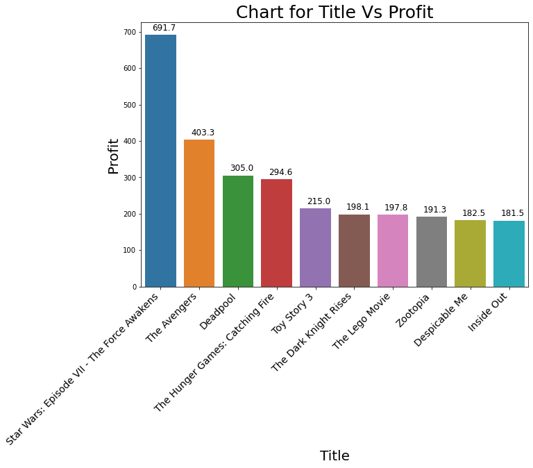

```python
bar_plot_fun(top10, "Title", "Profit")
```

#### Star Wars: The Force Awakens has made the most profit from Top 100 movies with 691.7 million dollars. The Avengers and Deadpool holds second and third position with 403 and 305 millions dollars respectively.

### Budget Vs Profit

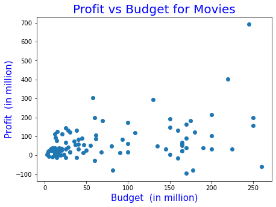

```python
plt.figure(figsize = (7,5))
plt.scatter(movies.budget, movies.Profit)

#Adding and formatting the title
plt.title("Profit vs Budget for Movies", fontdict = {'fontsize' : 20, 'color': 'Blue'})

#Adding x and y labels
plt.ylabel("Profit  (in million)", fontdict = {'fontsize' : 15, 'color': 'Blue'})
plt.xlabel("Budget  (in million)", fontdict = {'fontsize' : 15, 'color': 'Blue'})

plt.show()
```

#### Observations for above scatterplot

```
1. There are some movies with a smaller budget that have made a huge profit whereas there are some movies where despite having a big budget, they still failed to make a remarkable profit.
2. Even though these movies are present in top 100 movies, some movies have made negative profit. i.e They have faced
loses
```

The dataset contains the 100 best performing movies from the year 2010 to 2016. However scatter plot tells a different story. There are some movies with negative profit. Although good movies do incur losses, but there appear to be quite a few movie with losses. Lets have a closer look at this by finding the movies with negative profit.

```python
#Find the movies with negative profit

neg_profit = movies[movies['Profit']<0]

# to check new dataframe
neg_profit
```

|  | Title | title_year | budget | Gross | actor_1_name | actor_2_name | actor_3_name | actor_1_facebook_likes | actor_2_facebook_likes | actor_3_facebook_likes | IMDb_rating | genre_1 | genre_2 | genre_3 | MetaCritic | Runtime | CVotes10 | CVotes09 | CVotes08 | CVotes07 | CVotes06 | CVotes05 | CVotes04 | CVotes03 | CVotes02 | CVotes01 | CVotesMale | CVotesFemale | CVotesU18 | … |
| --- | --- | --- | --- | --- | --- | --- | --- | --- | --- | --- | --- | --- | --- | --- | --- | --- | --- | --- | --- | --- | --- | --- | --- | --- | --- | --- | --- | --- | --- | --- |
| 7 | Tangled | 2010 | 260.0 | 200.807262 | Brad Garrett | Donna Murphy | M.C. Gainey | 799 | 553.0 | 284.0 | 7.8 | Animation | Adventure | Comedy | 71.0 | 124 | 56575 | 54688 | 97207 | 70947 | 26805 | 8530 | 3043 | 1396 | 805 | 1606 | 166088 | 97213 | 1950 | … |
| 17 | Edge of Tomorrow | 2014 | 178.0 | 100.189501 | Tom Cruise | Lara Pulver | Noah Taylor | 10000 | 854.0 | 509.0 | 7.9 | Action | Adventure | Sci-Fi | 71.0 | 113 | 60383 | 99596 | 175961 | 100724 | 28982 | 8145 | 2858 | 1368 | 857 | 1661 | 341199 | 45790 | 1893 | … |
| 22 | Hugo | 2011 | 170.0 | 73.820094 | ChloÃ« Grace Moretz | Christopher Lee | Ray Winstone | 17000 | 16000.0 | 1000.0 | 7.5 | Adventure | Drama | Family | 83.0 | 126 | 29228 | 40728 | 77893 | 62936 | 27932 | 11179 | 4664 | 2674 | 1700 | 3023 | 179655 | 47795 | 884 | … |
| 28 | X-Men: First Class | 2011 | 160.0 | 146.405371 | Jennifer Lawrence | Michael Fassbender | Oliver Platt | 34000 | 13000.0 | 1000.0 | 7.8 | Action | Adventure | Sci-Fi | 65.0 | 132 | 64428 | 96219 | 200144 | 129352 | 41945 | 12861 | 4799 | 2349 | 1448 | 3182 | 382107 | 80444 | 2075 | … |
| 39 | The Little Prince | 2015 | 81.2 | 1.339152 | Jeff Bridges | James Franco | Mackenzie Foy | 12000 | 11000.0 | 6000.0 | 7.8 | Animation | Adventure | Drama | 70.0 | 108 | 7565 | 7321 | 11668 | 8558 | 3370 | 1162 | 456 | 227 | 158 | 293 | 22441 | 9552 | 226 | … |
| 46 | Scott Pilgrim vs. the World | 2010 | 60.0 | 31.494270 | Anna Kendrick | Kieran Culkin | Ellen Wong | 10000 | 1000.0 | 719.0 | 7.5 | Action | Comedy | Romance | 69.0 | 112 | 47292 | 48976 | 79198 | 59689 | 28452 | 13451 | 6977 | 4254 | 3069 | 6287 | 208417 | 45718 | 1022 | … |
| 56 | Rush | 2013 | 38.0 | 26.903709 | Chris Hemsworth | Olivia Wilde | Alexandra Maria Lara | 26000 | 10000.0 | 471.0 | 8.1 | Action | Biography | Drama | 75.0 | 123 | 53667 | 90907 | 119603 | 57343 | 14948 | 4436 | 1625 | 803 | 633 | 1532 | 246354 | 35289 | 888 | … |
| 66 | Warrior | 2011 | 25.0 | 13.651662 | Tom Hardy | Frank Grillo | Kevin Dunn | 27000 | 798.0 | 581.0 | 8.2 | Action | Drama | Sport | 71.0 | 140 | 74983 | 96953 | 106673 | 52972 | 16668 | 5727 | 2353 | 1205 | 1050 | 2479 | 270734 | 31075 | 673 | … |
| 82 | Flipped | 2010 | 14.0 | 1.752214 | Madeline Carroll | Rebecca De Mornay | Aidan Quinn | 1000 | 872.0 | 767.0 | 7.7 | Comedy | Drama | Romance | NaN | 124 | 11354 | 11050 | 20808 | 14372 | 5412 | 1848 | 664 | 321 | 230 | 402 | 33714 | 22540 | 320 | … |
| 89 | Amour | 2012 | 8.9 | 0.225377 | Isabelle Huppert | Emmanuelle Riva | Jean-Louis Trintignant | 678 | 432.0 | 319.0 | 7.9 | Drama | Romance | NaN | 94.0 | 127 | 11093 | 15944 | 22942 | 14187 | 5945 | 2585 | 1188 | 710 | 534 | 995 | 49808 | 16719 | 121 | … |
| 99 | Tucker and Dale vs Evil | 2010 | 5.0 | 0.223838 | Katrina Bowden | Tyler Labine | Chelan Simmons | 948 | 779.0 | 440.0 | 7.6 | Comedy | Horror | NaN | 65.0 | 124 | 16572 | 19818 | 44460 | 35863 | 13456 | 4588 | 1684 | 855 | 479 | 848 | 106144 | 15113 | 219 | … |

```python
# to get number of rows and columns of neg_profit dataframe
neg_profit.shape
```

```
(11, 63)
```

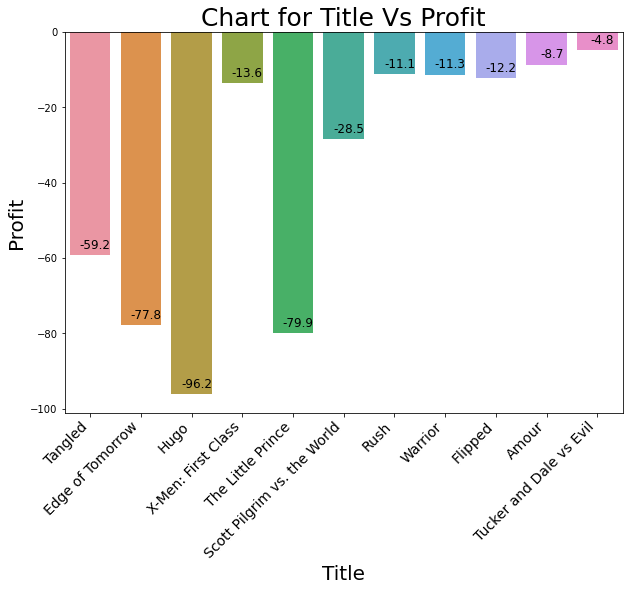

```python
bar_plot_fun(neg_profit, "Title", "Profit")
```

#### 1. Above plot shows that 'Hugo' movie has suffered a loss of 96.2 million dollars followed by 'The Little Prince' and 'Edge of Tomorrow'

#### 2. Despite of having IMDB rating of 8.1 and 8.2, movies 'Rush' and 'Warrior' have suffered some loss as well

### Let's check popularity of Content Rating

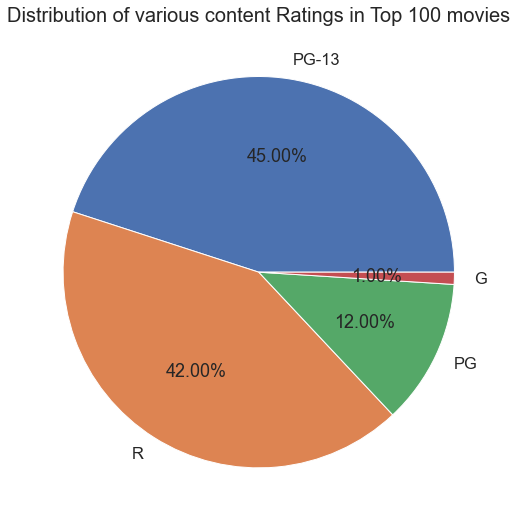

```python
y = list(movies["content_rating"].value_counts().index)
sns.set(font_scale=1.5)
bfig1, ax1 = plt.subplots(figsize=(9,9))
ax1.pie(movies["content_rating"].value_counts(),  labels = y, autopct = '%1.2f%%')
plt.title('Distribution of various content Ratings in Top 100 movies', fontsize = 20)
plt.show()
```

#### Majority of movies are PG-13 and R rated in Top 100 movies

### Let's check Origin of the movies

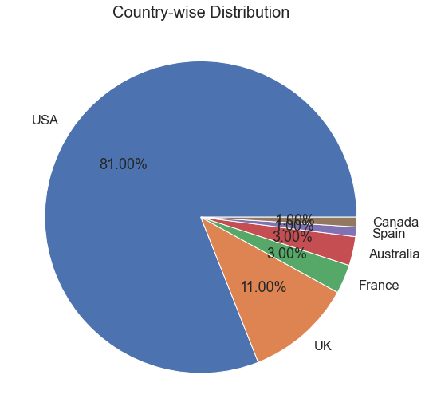

```python
fig1, ax = plt.subplots(figsize=(9,9))
sns.set(font_scale=1.5)
x = list(movies["Country"].value_counts().index)
ax.pie(movies["Country"].value_counts(),  labels = x, autopct = '%1.2f%%')
plt.title('Country-wise Distribution', fontsize = 20)
plt.show()
```

#### 81% of Top 100 movies has been made in USA and 11% of the movies are from UK

### The General Audience and the Critics

Column `MetaCritic` is a very popular website where an average score is determined through the scores given by the top-rated critics. Also there is another column `IMDb_rating` which gives the IMDb rating of a movie. This rating is determined by taking the average of hundred-thousands of ratings from the general audience.

#### Finding out the highest rated movies which have been liked by critics and audiences alike.

```python
# Changing the scale of MetaCritic

movies['MetaCritic'] = movies.MetaCritic/10
```

```python
# Finding average ratings

movies['Avg_rating'] = (movies['MetaCritic'] + movies['IMDb_rating'])/2
#Sorting in descending order of average rating

movies.sort_values('Avg_rating', ascending = False, inplace = True)
movies.head()
```

|  | Title | title_year | budget | Gross | actor_1_name | actor_2_name | actor_3_name | actor_1_facebook_likes | actor_2_facebook_likes | actor_3_facebook_likes | IMDb_rating | genre_1 | genre_2 | genre_3 | MetaCritic | Runtime | CVotes10 | CVotes09 | CVotes08 | CVotes07 | CVotes06 | CVotes05 | CVotes04 | CVotes03 | CVotes02 | CVotes01 | CVotesMale | CVotesFemale | CVotesU18 | … |
| --- | --- | --- | --- | --- | --- | --- | --- | --- | --- | --- | --- | --- | --- | --- | --- | --- | --- | --- | --- | --- | --- | --- | --- | --- | --- | --- | --- | --- | --- | --- |
| 94 | Boyhood | 2014 | 4.0 | 25.359200 | Ellar Coltrane | Lorelei Linklater | Libby Villari | 230 | 193.0 | 127.0 | 7.9 | Drama | NaN | NaN | 10.0 | 165 | 49673 | 62055 | 76838 | 52238 | 23789 | 10431 | 4906 | 3071 | 2248 | 5086 | 183807 | 51558 | 1393 | … |
| 69 | 12 Years a Slave | 2013 | 20.0 | 56.667870 | QuvenzhanÃ© Wallis | Scoot McNairy | Taran Killam | 2000 | 660.0 | 500.0 | 8.1 | Biography | Drama | History | 9.6 | 134 | 75556 | 126223 | 161460 | 83070 | 27231 | 9603 | 4021 | 2420 | 1785 | 4739 | 313823 | 82012 | 1837 | … |
| 18 | Inside Out | 2015 | 175.0 | 356.454367 | Amy Poehler | Mindy Kaling | Phyllis Smith | 1000 | 767.0 | 384.0 | 8.2 | Animation | Adventure | Comedy | 9.4 | 95 | 87509 | 113244 | 119801 | 67153 | 24210 | 8542 | 3349 | 1872 | 1123 | 3450 | 244433 | 79081 | 3361 | … |
| 0 | La La Land | 2016 | 30.0 | 151.101803 | Ryan Gosling | Emma Stone | Amiée Conn | 14000 | 19000.0 | NaN | 8.2 | Comedy | Drama | Music | 9.3 | 128 | 74245 | 71191 | 64640 | 38831 | 17377 | 8044 | 3998 | 2839 | 2407 | 6802 | 157693 | 56713 | 2675 | … |
| 12 | Toy Story 3 | 2010 | 200.0 | 414.984497 | Tom Hanks | John Ratzenberger | Don Rickles | 15000 | 1000.0 | 721.0 | 8.3 | Animation | Adventure | Comedy | 9.2 | 103 | 139773 | 149992 | 158704 | 88289 | 31291 | 11850 | 4859 | 2932 | 2119 | 6586 | 389014 | 98386 | 3202 | … |

```python
# Find the movies with metacritic-rating < 0.5 and also with the average rating of >8

movies['Diff_rating'] = abs(movies['IMDb_rating'] - movies['MetaCritic'])
UniversalAcclaim = movies[(movies['Diff_rating']<0.5) & (movies['Avg_rating'] >= 8)]
UniversalAcclaim
```

|  | Title | title_year | budget | Gross | actor_1_name | actor_2_name | actor_3_name | actor_1_facebook_likes | actor_2_facebook_likes | actor_3_facebook_likes | IMDb_rating | genre_1 | genre_2 | genre_3 | MetaCritic | Runtime | CVotes10 | CVotes09 | CVotes08 | CVotes07 | CVotes06 | CVotes05 | CVotes04 | CVotes03 | CVotes02 | CVotes01 | CVotesMale | CVotesFemale | CVotesU18 | … |
| --- | --- | --- | --- | --- | --- | --- | --- | --- | --- | --- | --- | --- | --- | --- | --- | --- | --- | --- | --- | --- | --- | --- | --- | --- | --- | --- | --- | --- | --- | --- |
| 95 | Whiplash | 2014 | 3.3 | 13.092000 | J.K. Simmons | Melissa Benoist | Chris Mulkey | 24000 | 970.0 | 535.0 | 8.5 | Drama | Music | NaN | 8.8 | 107 | 110404 | 161864 | 132656 | 56007 | 16577 | 6031 | 2937 | 1859 | 1263 | 2723 | 308900 | 71066 | 2878 | … |
| 35 | Django Unchained | 2012 | 100.0 | 162.804648 | Leonardo DiCaprio | Christoph Waltz | Ato Essandoh | 29000 | 11000.0 | 265.0 | 8.4 | Drama | Western | NaN | 8.1 | 165 | 234824 | 339329 | 286911 | 121445 | 38251 | 14227 | 6469 | 4149 | 3181 | 8065 | 695211 | 139226 | 3250 | … |
| 93 | Dallas Buyers Club | 2013 | 5.0 | 27.296514 | Matthew McConaughey | Jennifer Garner | Denis O'Hare | 11000 | 3000.0 | 896.0 | 8.0 | Biography | Drama | NaN | 8.4 | 117 | 37544 | 82276 | 145488 | 66156 | 16777 | 4582 | 1721 | 870 | 654 | 1588 | 231258 | 63266 | 864 | … |
| 97 | Star Wars: Episode VII - The Force Awakens | 2015 | 245.0 | 936.662225 | Doug Walker | Rob Walker | 0 | 131 | 12.0 | 0.0 | 8.1 | Action | Adventure | Fantasy | 8.1 | 136 | 155391 | 161810 | 166378 | 99402 | 40734 | 18060 | 8751 | 5970 | 4489 | 15768 | 425971 | 68664 | 4722 | … |
| 3 | Arrival | 2016 | 47.0 | 100.546139 | Amy Adams | Jeremy Renner | Forest Whitaker | 35000 | 5300.0 | NaN | 8.0 | Drama | Mystery | Sci-Fi | 8.1 | 116 | 55533 | 87850 | 109536 | 65440 | 26913 | 10556 | 5057 | 3083 | 2194 | 4734 | 237437 | 46272 | 1943 | … |
| 33 | The Martian | 2015 | 108.0 | 228.430993 | Matt Damon | Donald Glover | Benedict Wong | 13000 | 801.0 | 372.0 | 8.0 | Adventure | Drama | Sci-Fi | 8.0 | 144 | 75560 | 139593 | 200315 | 102723 | 31179 | 9930 | 3815 | 2046 | 1316 | 2907 | 359265 | 71421 | 3206 | … |
| 43 | Gone Girl | 2014 | 61.0 | 167.735396 | Patrick Fugit | Sela Ward | Emily Ratajkowski | 835 | 812.0 | 625.0 | 8.1 | Crime | Drama | Mystery | 7.9 | 149 | 89539 | 177373 | 218018 | 103600 | 32989 | 11691 | 5285 | 3262 | 2247 | 5500 | 397571 | 113606 | 2286 | … |

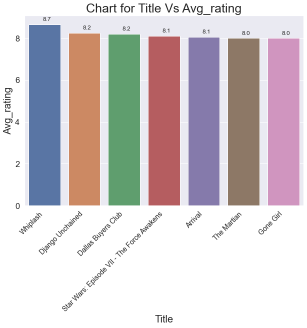

```python
bar_plot_fun(UniversalAcclaim, "Title", "Avg_rating")
```

#### We got above top rated list of movies by finding average of Critics rating and IMDB rating. These movies were liked by general audience and critics both.

```python
# to reset movie index

movies.reset_index(inplace = True, drop = True)
```

### Let's the Most Popular Trios

The metric that we have chosen to check the popularity is the Facebook likes of each of all the actors.

The dataframe has three columns to help you out for the same, viz. `actor_1_facebook_likes`, `actor_2_facebook_likes`, and `actor_3_facebook_likes`. Our objective is to find the trios which has the most number of Facebook likes combined. That is, the sum of `actor_1_facebook_likes`, `actor_2_facebook_likes` and `actor_3_facebook_likes` should be maximum. Finding out the top 5 popular trios, and output their names in a list.

```python
# to covert datatype of 'actor_1_facebook_likes' column to float64

movies.actor_1_facebook_likes = movies.actor_1_facebook_likes.astype('float64')
# Extraxting necessary columns in new dataframe
actor_trio = movies[['actor_1_name','actor_2_name','actor_3_name','actor_1_facebook_likes','actor_2_facebook_likes','actor_3_facebook_likes']]

# adding facebook likes of all actors
actor_trio['Total_likes'] = movies['actor_1_facebook_likes'] + movies['actor_2_facebook_likes'] + movies['actor_3_facebook_likes']
actor_trio.head()
```

|  | actor_1_name | actor_2_name | actor_3_name | actor_1_facebook_likes | actor_2_facebook_likes | actor_3_facebook_likes | Total_likes |
| --- | --- | --- | --- | --- | --- | --- | --- |
| 0 | Ellar Coltrane | Lorelei Linklater | Libby Villari | 230.0 | 193.0 | 127.0 | 550.0 |
| 1 | QuvenzhanÃ© Wallis | Scoot McNairy | Taran Killam | 2000.0 | 660.0 | 500.0 | 3160.0 |
| 2 | Amy Poehler | Mindy Kaling | Phyllis Smith | 1000.0 | 767.0 | 384.0 | 2151.0 |
| 3 | Ryan Gosling | Emma Stone | Amiée Conn | 14000.0 | 19000.0 | NaN | NaN |
| 4 | Tom Hanks | John Ratzenberger | Don Rickles | 15000.0 | 1000.0 | 721.0 | 16721.0 |

```python
# sorting to arrange according to popularity

sorted_trio = actor_trio.sort_values('Total_likes', ascending = False)
Top5 = sorted_trio.head()
```

```python
# to get names of top 5 popular trios from dataframe to a list

Top5["Trio"] = Top5['actor_1_name']+" | "+Top5['actor_2_name']+" | "+Top5['actor_3_name']
Top5
```

|  | actor_1_name | actor_2_name | actor_3_name | actor_1_facebook_likes | actor_2_facebook_likes | actor_3_facebook_likes | Total_likes | Trio |
| --- | --- | --- | --- | --- | --- | --- | --- | --- |
| 68 | Dev Patel | Nicole Kidman | Rooney Mara | 33000.0 | 96000.0 | 9800.0 | 138800.0 | Dev Patel \| Nicole Kidman \| Rooney Mara |
| 24 | Leonardo DiCaprio | Tom Hardy | Joseph Gordon-Levitt | 29000.0 | 27000.0 | 23000.0 | 79000.0 | Leonardo DiCaprio \| Tom Hardy \| Joseph Gordon-... |
| 58 | Jennifer Lawrence | Peter Dinklage | Hugh Jackman | 34000.0 | 22000.0 | 20000.0 | 76000.0 | Jennifer Lawrence \| Peter Dinklage \| Hugh Jackman |
| 5 | Casey Affleck | Michelle Williams | Kyle Chandler | 518.0 | 71000.0 | 3300.0 | 74818.0 | Casey Affleck \| Michelle Williams \| Kyle Chan... |
| 26 | Tom Hardy | Christian Bale | Joseph Gordon-Levitt | 27000.0 | 23000.0 | 23000.0 | 73000.0 | Tom Hardy \| Christian Bale \| Joseph Gordon-Levitt |

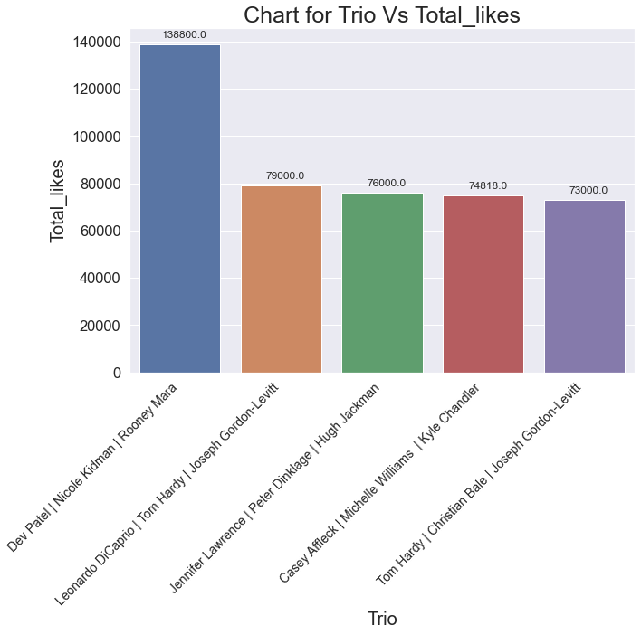

```python
bar_plot_fun(Top5, "Trio", "Total_likes")
```

#### Dev Patel, Nicole Kidman and Rooney Mara trio has received the most likes combined, making it the most popular trio.

## Runtime Analysis

There is a column named `Runtime` in the dataframe which primarily shows the length of the movie. It might be intersting to see how this variable this distributed. Ploting a `histogram` or `distplot` of seaborn to find the `Runtime` range most of the movies fall into.

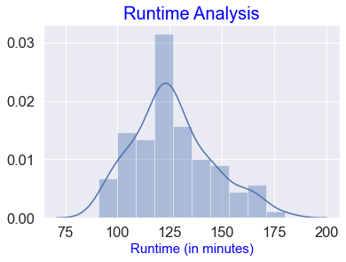

```python
# Runtime histogram/density plot

sns.distplot(movies['Runtime'])
plt.title('Runtime Analysis', fontdict = {'fontsize' : 20, 'color': 'Blue'})
plt.xlabel('Runtime (in minutes)', fontdict = {'fontsize' : 15, 'color': 'Blue'})
plt.show()
```

#### Most of the Top 100 movies appear to be sharply 2 hour-long.

## R-Rated Movies Analysis

Although R rated movies are restricted movies for the under 18 age group, still there are vote counts from that age group. Among all the R rated movies that have been voted by the under-18 age group, Let's find the top 10 movies that have the highest number of votes i.e.`CVotesU18`

```python
# Extracting R-rated movies

R_df = movies[movies['content_rating']=='R']

# sorting in descending order for highest number of votes
PopularR = R_df.sort_values('CVotesU18', ascending = False).head(10)
```

```python
PopularR
```

|  | Title | title_year | budget | Gross | actor_1_name | actor_2_name | actor_3_name | actor_1_facebook_likes | actor_2_facebook_likes | actor_3_facebook_likes | IMDb_rating | genre_1 | genre_2 | genre_3 | MetaCritic | Runtime | CVotes10 | CVotes09 | CVotes08 | CVotes07 | CVotes06 | CVotes05 | CVotes04 | CVotes03 | CVotes02 | CVotes01 | CVotesMale | CVotesFemale | CVotesU18 | … |
| --- | --- | --- | --- | --- | --- | --- | --- | --- | --- | --- | --- | --- | --- | --- | --- | --- | --- | --- | --- | --- | --- | --- | --- | --- | --- | --- | --- | --- | --- | --- |
| 82 | Deadpool | 2016 | 58.0 | 363.024263 | Ryan Reynolds | Ed Skrein | Stefan Kapicic | 16000.0 | 805.0 | 361.0 | 8.0 | Action | Adventure | Comedy | 6.5 | 108 | 147467 | 147966 | 170810 | 105717 | 41811 | 15510 | 7046 | 4273 | 3037 | 8538 | 391955 | 79804 | 4598 | … |
| 47 | The Wolf of Wall Street | 2013 | 100.0 | 116.866727 | Leonardo DiCaprio | Matthew McConaughey | Jon Favreau | 29000.0 | 11000.0 | 4000.0 | 8.2 | Biography | Comedy | Crime | 7.5 | 180 | 171660 | 236650 | 250667 | 129164 | 46715 | 18682 | 8674 | 5854 | 4258 | 9689 | 559564 | 123698 | 3622 | … |
| 19 | Django Unchained | 2012 | 100.0 | 162.804648 | Leonardo DiCaprio | Christoph Waltz | Ato Essandoh | 29000.0 | 11000.0 | 265.0 | 8.4 | Drama | Western | NaN | 8.1 | 165 | 234824 | 339329 | 286911 | 121445 | 38251 | 14227 | 6469 | 4149 | 3181 | 8065 | 695211 | 139226 | 3250 | … |
| 12 | Mad Max: Fury Road | 2015 | 150.0 | 153.629485 | Tom Hardy | Charlize Theron | ZoÃ« Kravitz | 27000.0 | 9000.0 | 943.0 | 8.1 | Action | Adventure | Sci-Fi | 9.0 | 120 | 136194 | 158403 | 163494 | 97218 | 42636 | 19505 | 9932 | 6743 | 4930 | 10516 | 424435 | 69670 | 3159 | … |
| 9 | Whiplash | 2014 | 3.3 | 13.092000 | J.K. Simmons | Melissa Benoist | Chris Mulkey | 24000.0 | 970.0 | 535.0 | 8.5 | Drama | Music | NaN | 8.8 | 107 | 110404 | 161864 | 132656 | 56007 | 16577 | 6031 | 2937 | 1859 | 1263 | 2723 | 308900 | 71066 | 2878 | … |
| 51 | The Revenant | 2015 | 135.0 | 183.635922 | Leonardo DiCaprio | Tom Hardy | Lukas Haas | 29000.0 | 27000.0 | 733.0 | 8.0 | Adventure | Drama | Thriller | 7.6 | 156 | 79977 | 121229 | 158019 | 91154 | 33492 | 12837 | 5571 | 3386 | 2320 | 4570 | 323938 | 61051 | 2619 | … |
| 86 | Shutter Island | 2010 | 80.0 | 127.968405 | Leonardo DiCaprio | Joseph Sikora | Nellie Sciutto | 29000.0 | 223.0 | 163.0 | 8.1 | Mystery | Thriller | NaN | 6.3 | 138 | 150405 | 230844 | 278844 | 132349 | 45167 | 15615 | 7061 | 3780 | 2662 | 4703 | 570554 | 136360 | 2321 | … |
| 32 | Gone Girl | 2014 | 61.0 | 167.735396 | Patrick Fugit | Sela Ward | Emily Ratajkowski | 835.0 | 812.0 | 625.0 | 8.1 | Crime | Drama | Mystery | 7.9 | 149 | 89539 | 177373 | 218018 | 103600 | 32989 | 11691 | 5285 | 3262 | 2247 | 5500 | 397571 | 113606 | 2286 | … |
| 14 | The Grand Budapest Hotel | 2014 | 25.0 | 59.073773 | Bill Murray | Tom Wilkinson | F. Murray Abraham | 13000.0 | 1000.0 | 670.0 | 8.1 | Adventure | Comedy | Drama | 8.8 | 99 | 84258 | 142011 | 168705 | 88086 | 31632 | 12023 | 5455 | 3196 | 2204 | 3971 | 332149 | 96997 | 2083 | … |
| 17 | Birdman or (The Unexpected Virtue of Ignorance) | 2014 | 18.0 | 42.335698 | Emma Stone | Naomi Watts | Merritt Wever | 15000.0 | 6000.0 | 529.0 | 7.8 | Comedy | Drama | NaN | 8.8 | 119 | 60209 | 94476 | 121637 | 80828 | 38373 | 19161 | 10116 | 6750 | 5378 | 11807 | 292808 | 63310 | 1891 | … |

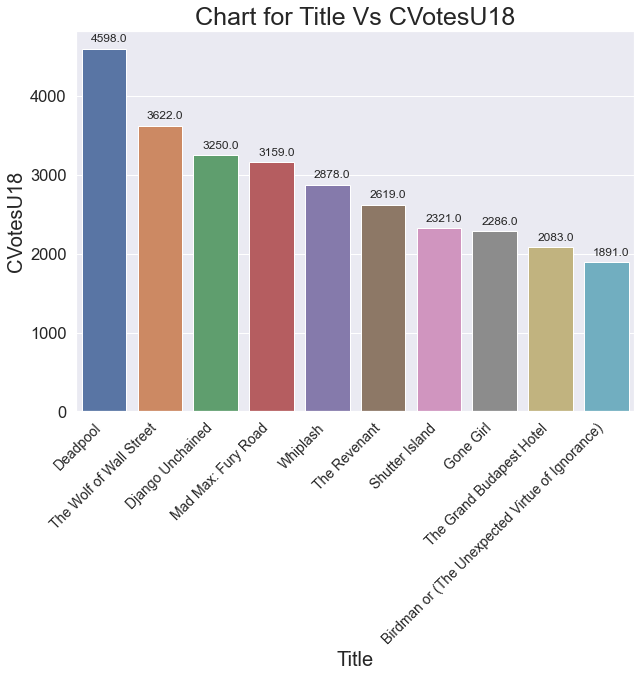

```python
bar_plot_fun(PopularR, 'Title', 'CVotesU18')
```

#### It seems that many kids are watching Deadpool despite of the movie being R-rated.

## Know your Audience!

If we take a look at the last columns in the dataframe, most of these are related to demographics of the voters. We also have three genre columns indicating the genres of a particular movie.

There are 3 columns in the dataframe - `genre_1`, `genre_2`, and `genre_3`. We need to aggregate a few values over these 3 columns for further analysis.

```python
# to fetch genre columns and columns consisting votes

genre = movies.iloc[:,11:14]
votes = movies.iloc[:,16:60]
```

```python
# Create the dataframe df_by_genre

df_by_genre = pd.concat([genre, votes], axis = 1)

# to verify number of columns (should be 47)
df_by_genre.shape
```

```
(100, 47)
```

```python
# Create a column cnt and initialize it to 1

df_by_genre['cnt'] = 1
df_by_genre.head()
```

|  | genre_1 | genre_2 | genre_3 | CVotes10 | CVotes09 | CVotes08 | CVotes07 | CVotes06 | CVotes05 | CVotes04 | CVotes03 | CVotes02 | CVotes01 | CVotesMale | CVotesFemale | CVotesU18 | CVotesU18M | CVotesU18F | CVotes1829 | CVotes1829M | CVotes1829F | CVotes3044 | CVotes3044M | CVotes3044F | CVotes45A | CVotes45AM | CVotes45AF | CVotes1000 | CVotesUS | … |
| --- | --- | --- | --- | --- | --- | --- | --- | --- | --- | --- | --- | --- | --- | --- | --- | --- | --- | --- | --- | --- | --- | --- | --- | --- | --- | --- | --- | --- | --- | --- |
| 0 | Drama | NaN | NaN | 49673 | 62055 | 76838 | 52238 | 23789 | 10431 | 4906 | 3071 | 2248 | 5086 | 183807 | 51558 | 1393 | 995 | 381 | 123006 | 92639 | 29076 | 81594 | 65261 | 15118 | 17881 | 13995 | 3567 | 559 | 36433 | … |
| 1 | Biography | Drama | History | 75556 | 126223 | 161460 | 83070 | 27231 | 9603 | 4021 | 2420 | 1785 | 4739 | 313823 | 82012 | 1837 | 1363 | 457 | 200910 | 153669 | 45301 | 138762 | 112943 | 23895 | 29252 | 23072 | 5726 | 664 | 53328 | … |
| 2 | Animation | Adventure | Comedy | 87509 | 113244 | 119801 | 67153 | 24210 | 8542 | 3349 | 1872 | 1123 | 3450 | 244433 | 79081 | 3361 | 2294 | 1040 | 170056 | 121574 | 46685 | 108560 | 86312 | 20516 | 18694 | 14910 | 3416 | 587 | 48297 | … |
| 3 | Comedy | Drama | Music | 74245 | 71191 | 64640 | 38831 | 17377 | 8044 | 3998 | 2839 | 2407 | 6802 | 157693 | 56713 | 2675 | 1784 | 868 | 113008 | 78998 | 32730 | 66058 | 50835 | 14165 | 15765 | 12148 | 3302 | 454 | 33360 | … |
| 4 | Animation | Adventure | Comedy | 139773 | 149992 | 158704 | 88289 | 31291 | 11850 | 4859 | 2932 | 2119 | 6586 | 389014 | 98386 | 3202 | 2405 | 776 | 260519 | 199962 | 58366 | 169886 | 140253 | 27658 | 32457 | 26171 | 5806 | 769 | 105490 | … |

```python
# Group the movies by individual genres

df_by_g1 = df_by_genre.groupby(['genre_1'], axis = 0).sum()
df_by_g2 = df_by_genre.groupby(['genre_2'], axis = 0).sum()
df_by_g3 = df_by_genre.groupby(['genre_3'], axis = 0).sum()

# Add the grouped data frames and store it in a new data frame

df_add = df_by_g1.add(df_by_g2, fill_value = 0).add(df_by_g3, fill_value = 0)
df_add
```

|  | CVotes10 | CVotes09 | CVotes08 | CVotes07 | CVotes06 | CVotes05 | CVotes04 | CVotes03 | CVotes02 | CVotes01 | CVotesMale | CVotesFemale | CVotesU18 | CVotesU18M | CVotesU18F | CVotes1829 | CVotes1829M | CVotes1829F | CVotes3044 | CVotes3044M | CVotes3044F | CVotes45A | CVotes45AM | CVotes45AF | CVotes1000 | CVotesUS | CVotesnUS | VotesM | VotesF | … |
| --- | --- | --- | --- | --- | --- | --- | --- | --- | --- | --- | --- | --- | --- | --- | --- | --- | --- | --- | --- | --- | --- | --- | --- | --- | --- | --- | --- | --- | --- | --- |
| Action | 3166467.0 | 3547429.0 | 4677755.0 | 2922126.0 | 1075354.0 | 393484.0 | 166970.0 | 95004.0 | 65573.0 | 171247.0 | 10837034.0 | 2105410.0 | 76280.0 | 59424.0 | 16302.0 | 6314227.0 | 5105793.0 | 1146894.0 | 4824318.0 | 4117926.0 | 639437.0 | 894736.0 | 746866.0 | 132357.0 | 21123.0 | 2144895.0 | 7005964.0 | 243.2 | 245.6 | … |
| Adventure | 3594659.0 | 4014192.0 | 5262328.0 | 3281981.0 | 1212075.0 | 438970.0 | 183070.0 | 103318.0 | 69737.0 | 173858.0 | 11759815.0 | 2705904.0 | 95791.0 | 72215.0 | 22864.0 | 7165429.0 | 5578727.0 | 1516049.0 | 5262641.0 | 4400217.0 | 788533.0 | 1012382.0 | 832607.0 | 162152.0 | 25157.0 | 2345901.0 | 7905326.0 | 298.4 | 304.5 | … |
| Animation | 681562.0 | 798227.0 | 1153214.0 | 722782.0 | 251076.0 | 83069.0 | 30718.0 | 15733.0 | 10026.0 | 25193.0 | 2282985.0 | 724844.0 | 23835.0 | 16354.0 | 7307.0 | 1588630.0 | 1140646.0 | 432464.0 | 1043387.0 | 834069.0 | 195268.0 | 179365.0 | 142636.0 | 33699.0 | 6364.0 | 524406.0 | 1654665.0 | 86.4 | 89.3 | … |
| Biography | 852003.0 | 1401608.0 | 2231078.0 | 1332980.0 | 425595.0 | 138648.0 | 53718.0 | 29510.0 | 20613.0 | 51297.0 | 4329471.0 | 986889.0 | 20937.0 | 15962.0 | 4780.0 | 2603294.0 | 2052779.0 | 524830.0 | 1999316.0 | 1658844.0 | 312373.0 | 405909.0 | 324710.0 | 74280.0 | 10804.0 | 817016.0 | 3078088.0 | 141.1 | 141.8 | … |
| Comedy | 1383616.0 | 1774987.0 | 2506851.0 | 1591069.0 | 600287.0 | 226852.0 | 97469.0 | 56218.0 | 39391.0 | 88367.0 | 5223033.0 | 1498288.0 | 37971.0 | 27099.0 | 10574.0 | 3404755.0 | 2507369.0 | 862715.0 | 2453650.0 | 1985974.0 | 433363.0 | 458960.0 | 367532.0 | 83303.0 | 13934.0 | 1132079.0 | 3815002.0 | 180.2 | 181.2 | … |
| Crime | 574526.0 | 967118.0 | 1419495.0 | 821390.0 | 278391.0 | 98690.0 | 42271.0 | 24713.0 | 16985.0 | 37217.0 | 2881292.0 | 586638.0 | 12866.0 | 10253.0 | 2503.0 | 1677551.0 | 1349593.0 | 311413.0 | 1338103.0 | 1129391.0 | 190218.0 | 251542.0 | 206799.0 | 40242.0 | 6821.0 | 549216.0 | 1994718.0 | 86.6 | 84.9 | … |
| Drama | 3404438.0 | 4935375.0 | 7107053.0 | 4319700.0 | 1529356.0 | 552312.0 | 235475.0 | 135126.0 | 94185.0 | 211308.0 | 14668668.0 | 3572166.0 | 80847.0 | 59481.0 | 20608.0 | 8871540.0 | 6838230.0 | 1943300.0 | 6897952.0 | 5696903.0 | 1102691.0 | 1404823.0 | 1132442.0 | 247420.0 | 38086.0 | 2870687.0 | 10480222.0 | 509.8 | 510.3 | … |
| Family | 98165.0 | 95675.0 | 180381.0 | 143401.0 | 59137.0 | 22971.0 | 9472.0 | 5128.0 | 3317.0 | 7545.0 | 403523.0 | 127301.0 | 2851.0 | 1926.0 | 888.0 | 284685.0 | 205116.0 | 76732.0 | 187454.0 | 149201.0 | 35839.0 | 40213.0 | 31740.0 | 7815.0 | 1403.0 | 95266.0 | 323735.0 | 15.0 | 15.8 | … |
| Fantasy | 572452.0 | 602223.0 | 889767.0 | 599747.0 | 241831.0 | 93484.0 | 39403.0 | 22233.0 | 14693.0 | 38841.0 | 1963752.0 | 509053.0 | 15451.0 | 11704.0 | 3631.0 | 1235849.0 | 934069.0 | 289061.0 | 889082.0 | 728499.0 | 147645.0 | 181407.0 | 146943.0 | 31316.0 | 4609.0 | 378849.0 | 1391028.0 | 54.1 | 56.0 | … |
| History | 151261.0 | 260387.0 | 394531.0 | 223062.0 | 67861.0 | 21233.0 | 7964.0 | 4384.0 | 3148.0 | 9291.0 | 736411.0 | 163565.0 | 4640.0 | 3714.0 | 879.0 | 437514.0 | 347085.0 | 85999.0 | 329271.0 | 274405.0 | 50114.0 | 72947.0 | 58590.0 | 13092.0 | 2170.0 | 134572.0 | 511592.0 | 31.7 | 31.8 | … |
| Horror | 16572.0 | 19818.0 | 44460.0 | 35863.0 | 13456.0 | 4588.0 | 1684.0 | 855.0 | 479.0 | 848.0 | 106144.0 | 15113.0 | 219.0 | 198.0 | 20.0 | 52889.0 | 45169.0 | 7232.0 | 56379.0 | 49634.0 | 6156.0 | 8861.0 | 7645.0 | 1072.0 | 540.0 | 26213.0 | 73918.0 | 7.5 | 7.7 | … |
| Music | 184649.0 | 233055.0 | 197296.0 | 94838.0 | 33954.0 | 14075.0 | 6935.0 | 4698.0 | 3670.0 | 9525.0 | 466593.0 | 127779.0 | 5553.0 | 3984.0 | 1528.0 | 318847.0 | 240851.0 | 74674.0 | 189770.0 | 153674.0 | 33183.0 | 39110.0 | 31220.0 | 7114.0 | 1044.0 | 83228.0 | 331939.0 | 16.7 | 16.5 | … |
| Musical | 54268.0 | 47750.0 | 63323.0 | 45160.0 | 22393.0 | 10744.0 | 5551.0 | 3484.0 | 2490.0 | 5020.0 | 141014.0 | 73591.0 | 972.0 | 502.0 | 456.0 | 112609.0 | 68687.0 | 42720.0 | 69385.0 | 49760.0 | 18632.0 | 18404.0 | 12811.0 | 5282.0 | 623.0 | 42302.0 | 112787.0 | 7.5 | 7.9 | … |
| Mystery | 510164.0 | 827124.0 | 1166485.0 | 655612.0 | 228873.0 | 80568.0 | 34679.0 | 19392.0 | 13170.0 | 29444.0 | 2288130.0 | 574853.0 | 13112.0 | 9197.0 | 3794.0 | 1413996.0 | 1079996.0 | 320081.0 | 1067978.0 | 880660.0 | 172541.0 | 204262.0 | 165790.0 | 34860.0 | 4730.0 | 437197.0 | 1636257.0 | 55.2 | 55.8 | … |
| Romance | 549959.0 | 689492.0 | 1069280.0 | 712841.0 | 281289.0 | 110901.0 | 48913.0 | 27698.0 | 19200.0 | 40075.0 | 2114693.0 | 826446.0 | 13276.0 | 6959.0 | 6168.0 | 1536614.0 | 1027323.0 | 493050.0 | 1049990.0 | 809301.0 | 225561.0 | 204349.0 | 156714.0 | 43959.0 | 7130.0 | 482839.0 | 1706303.0 | 100.7 | 101.8 | … |
| Sci-Fi | 2325284.0 | 2530855.0 | 3002994.0 | 1802098.0 | 671811.0 | 254175.0 | 111925.0 | 65904.0 | 46171.0 | 114435.0 | 7181436.0 | 1421515.0 | 51305.0 | 40494.0 | 10431.0 | 4161743.0 | 3351092.0 | 769577.0 | 3204214.0 | 2722405.0 | 435556.0 | 614167.0 | 512399.0 | 90784.0 | 12146.0 | 1371825.0 | 4625171.0 | 135.4 | 135.3 | … |
| Sport | 117081.0 | 169246.0 | 273043.0 | 184163.0 | 60902.0 | 18939.0 | 6810.0 | 3357.0 | 2292.0 | 5234.0 | 619611.0 | 79286.0 | 1950.0 | 1744.0 | 193.0 | 329158.0 | 289487.0 | 36728.0 | 287009.0 | 253040.0 | 30192.0 | 47890.0 | 39999.0 | 7085.0 | 1705.0 | 126066.0 | 398650.0 | 23.4 | 23.0 | … |
| Thriller | 1081701.0 | 1465491.0 | 1993378.0 | 1175799.0 | 416046.0 | 149953.0 | 65281.0 | 37940.0 | 25767.0 | 57630.0 | 4339209.0 | 893747.0 | 21632.0 | 17252.0 | 4195.0 | 2541027.0 | 2035455.0 | 480861.0 | 1995184.0 | 1682474.0 | 284988.0 | 384675.0 | 317480.0 | 60502.0 | 8705.0 | 823702.0 | 2976280.0 | 102.3 | 101.6 | … |
| War | 52664.0 | 72310.0 | 143841.0 | 106966.0 | 40505.0 | 14401.0 | 5690.0 | 3114.0 | 1971.0 | 4001.0 | 298165.0 | 60168.0 | 1715.0 | 1234.0 | 466.0 | 169080.0 | 134926.0 | 32476.0 | 131400.0 | 112341.0 | 17236.0 | 31742.0 | 26416.0 | 4798.0 | 926.0 | 46595.0 | 200820.0 | 15.0 | 15.5 | … |
| Western | 255918.0 | 380230.0 | 378736.0 | 188620.0 | 61306.0 | 21418.0 | 9147.0 | 5454.0 | 3960.0 | 9737.0 | 892316.0 | 166351.0 | 3631.0 | 3066.0 | 536.0 | 499932.0 | 409554.0 | 85726.0 | 405432.0 | 345060.0 | 54937.0 | 83104.0 | 69420.0 | 12331.0 | 1563.0 | 177172.0 | 585798.0 | 16.1 | 16.0 | … |

```python
# Extract genres with atleast 10 occurences

genre_top10 = df_add[df_add['cnt'] >= 10]
genre_top10
```

|  | CVotes10 | CVotes09 | CVotes08 | CVotes07 | CVotes06 | CVotes05 | CVotes04 | CVotes03 | CVotes02 | CVotes01 | CVotesMale | CVotesFemale | CVotesU18 | CVotesU18M | CVotesU18F | CVotes1829 | CVotes1829M | CVotes1829F | CVotes3044 | CVotes3044M | CVotes3044F | CVotes45A | CVotes45AM | CVotes45AF | CVotes1000 | CVotesUS | CVotesnUS | VotesM | VotesF | … |
| --- | --- | --- | --- | --- | --- | --- | --- | --- | --- | --- | --- | --- | --- | --- | --- | --- | --- | --- | --- | --- | --- | --- | --- | --- | --- | --- | --- | --- | --- | --- |
| Action | 3166467.0 | 3547429.0 | 4677755.0 | 2922126.0 | 1075354.0 | 393484.0 | 166970.0 | 95004.0 | 65573.0 | 171247.0 | 10837034.0 | 2105410.0 | 76280.0 | 59424.0 | 16302.0 | 6314227.0 | 5105793.0 | 1146894.0 | 4824318.0 | 4117926.0 | 639437.0 | 894736.0 | 746866.0 | 132357.0 | 21123.0 | 2144895.0 | 7005964.0 | 243.2 | 245.6 | … |
| Adventure | 3594659.0 | 4014192.0 | 5262328.0 | 3281981.0 | 1212075.0 | 438970.0 | 183070.0 | 103318.0 | 69737.0 | 173858.0 | 11759815.0 | 2705904.0 | 95791.0 | 72215.0 | 22864.0 | 7165429.0 | 5578727.0 | 1516049.0 | 5262641.0 | 4400217.0 | 788533.0 | 1012382.0 | 832607.0 | 162152.0 | 25157.0 | 2345901.0 | 7905326.0 | 298.4 | 304.5 | … |
| Animation | 681562.0 | 798227.0 | 1153214.0 | 722782.0 | 251076.0 | 83069.0 | 30718.0 | 15733.0 | 10026.0 | 25193.0 | 2282985.0 | 724844.0 | 23835.0 | 16354.0 | 7307.0 | 1588630.0 | 1140646.0 | 432464.0 | 1043387.0 | 834069.0 | 195268.0 | 179365.0 | 142636.0 | 33699.0 | 6364.0 | 524406.0 | 1654665.0 | 86.4 | 89.3 | … |
| Biography | 852003.0 | 1401608.0 | 2231078.0 | 1332980.0 | 425595.0 | 138648.0 | 53718.0 | 29510.0 | 20613.0 | 51297.0 | 4329471.0 | 986889.0 | 20937.0 | 15962.0 | 4780.0 | 2603294.0 | 2052779.0 | 524830.0 | 1999316.0 | 1658844.0 | 312373.0 | 405909.0 | 324710.0 | 74280.0 | 10804.0 | 817016.0 | 3078088.0 | 141.1 | 141.8 | … |
| Comedy | 1383616.0 | 1774987.0 | 2506851.0 | 1591069.0 | 600287.0 | 226852.0 | 97469.0 | 56218.0 | 39391.0 | 88367.0 | 5223033.0 | 1498288.0 | 37971.0 | 27099.0 | 10574.0 | 3404755.0 | 2507369.0 | 862715.0 | 2453650.0 | 1985974.0 | 433363.0 | 458960.0 | 367532.0 | 83303.0 | 13934.0 | 1132079.0 | 3815002.0 | 180.2 | 181.2 | … |
| Crime | 574526.0 | 967118.0 | 1419495.0 | 821390.0 | 278391.0 | 98690.0 | 42271.0 | 24713.0 | 16985.0 | 37217.0 | 2881292.0 | 586638.0 | 12866.0 | 10253.0 | 2503.0 | 1677551.0 | 1349593.0 | 311413.0 | 1338103.0 | 1129391.0 | 190218.0 | 251542.0 | 206799.0 | 40242.0 | 6821.0 | 549216.0 | 1994718.0 | 86.6 | 84.9 | … |
| Drama | 3404438.0 | 4935375.0 | 7107053.0 | 4319700.0 | 1529356.0 | 552312.0 | 235475.0 | 135126.0 | 94185.0 | 211308.0 | 14668668.0 | 3572166.0 | 80847.0 | 59481.0 | 20608.0 | 8871540.0 | 6838230.0 | 1943300.0 | 6897952.0 | 5696903.0 | 1102691.0 | 1404823.0 | 1132442.0 | 247420.0 | 38086.0 | 2870687.0 | 10480222.0 | 509.8 | 510.3 | … |
| Romance | 549959.0 | 689492.0 | 1069280.0 | 712841.0 | 281289.0 | 110901.0 | 48913.0 | 27698.0 | 19200.0 | 40075.0 | 2114693.0 | 826446.0 | 13276.0 | 6959.0 | 6168.0 | 1536614.0 | 1027323.0 | 493050.0 | 1049990.0 | 809301.0 | 225561.0 | 204349.0 | 156714.0 | 43959.0 | 7130.0 | 482839.0 | 1706303.0 | 100.7 | 101.8 | … |
| Sci-Fi | 2325284.0 | 2530855.0 | 3002994.0 | 1802098.0 | 671811.0 | 254175.0 | 111925.0 | 65904.0 | 46171.0 | 114435.0 | 7181436.0 | 1421515.0 | 51305.0 | 40494.0 | 10431.0 | 4161743.0 | 3351092.0 | 769577.0 | 3204214.0 | 2722405.0 | 435556.0 | 614167.0 | 512399.0 | 90784.0 | 12146.0 | 1371825.0 | 4625171.0 | 135.4 | 135.3 | … |
| Thriller | 1081701.0 | 1465491.0 | 1993378.0 | 1175799.0 | 416046.0 | 149953.0 | 65281.0 | 37940.0 | 25767.0 | 57630.0 | 4339209.0 | 893747.0 | 21632.0 | 17252.0 | 4195.0 | 2541027.0 | 2035455.0 | 480861.0 | 1995184.0 | 1682474.0 | 284988.0 | 384675.0 | 317480.0 | 60502.0 | 8705.0 | 823702.0 | 2976280.0 | 102.3 | 101.6 | … |

```python
# verify rows of genre_top10

genre_top10.shape
```

```
(10, 45)
```

```python
# Take the mean for every column by dividing with cnt

genre_top10.iloc[:,0:44] = genre_top10.iloc[:,0:44].div(genre_top10['cnt'], axis=0)

# Rounding off the columns of Votes to two decimals

genre_top10.loc[:, "VotesM":"VotesnUS"] = genre_top10.loc[:, "VotesM":"VotesnUS"].round(decimals = 2)

# Converting CVotes to int type

genre_top10.loc[:, "CVotes10":"CVotesnUS"] = genre_top10.loc[:, "CVotes10":"CVotesnUS"].astype("int32")

# Checking the dataframe
genre_top10
```

|  | CVotes10 | CVotes09 | CVotes08 | CVotes07 | CVotes06 | CVotes05 | CVotes04 | CVotes03 | CVotes02 | CVotes01 | CVotesMale | CVotesFemale | CVotesU18 | CVotesU18M | CVotesU18F | CVotes1829 | CVotes1829M | CVotes1829F | CVotes3044 | CVotes3044M | CVotes3044F | CVotes45A | CVotes45AM | CVotes45AF | CVotes1000 | CVotesUS | CVotesnUS | VotesM | VotesF | … |
| --- | --- | --- | --- | --- | --- | --- | --- | --- | --- | --- | --- | --- | --- | --- | --- | --- | --- | --- | --- | --- | --- | --- | --- | --- | --- | --- | --- | --- | --- | --- |
| Action | 102144.0 | 114433.0 | 150895.0 | 94262.0 | 34688.0 | 12693.0 | 5386.0 | 3064.0 | 2115.0 | 5524.0 | 349581.0 | 67916.0 | 2460.0 | 1916.0 | 525.0 | 203684.0 | 164703.0 | 36996.0 | 155623.0 | 132836.0 | 20627.0 | 28862.0 | 24092.0 | 4269.0 | 681.0 | 69190.0 | 225998.0 | 7.85 | 7.92 | … |
| Adventure | 94596.0 | 105636.0 | 138482.0 | 86367.0 | 31896.0 | 11551.0 | 4817.0 | 2718.0 | 1835.0 | 4575.0 | 309468.0 | 71208.0 | 2520.0 | 1900.0 | 601.0 | 188563.0 | 146808.0 | 39896.0 | 138490.0 | 115795.0 | 20750.0 | 26641.0 | 21910.0 | 4267.0 | 662.0 | 61734.0 | 208034.0 | 7.85 | 8.01 | … |
| Animation | 61960.0 | 72566.0 | 104837.0 | 65707.0 | 22825.0 | 7551.0 | 2792.0 | 1430.0 | 911.0 | 2290.0 | 207544.0 | 65894.0 | 2166.0 | 1486.0 | 664.0 | 144420.0 | 103695.0 | 39314.0 | 94853.0 | 75824.0 | 17751.0 | 16305.0 | 12966.0 | 3063.0 | 578.0 | 47673.0 | 150424.0 | 7.85 | 8.12 | … |
| Biography | 47333.0 | 77867.0 | 123948.0 | 74054.0 | 23644.0 | 7702.0 | 2984.0 | 1639.0 | 1145.0 | 2849.0 | 240526.0 | 54827.0 | 1163.0 | 886.0 | 265.0 | 144627.0 | 114043.0 | 29157.0 | 111073.0 | 92158.0 | 17354.0 | 22550.0 | 18039.0 | 4126.0 | 600.0 | 45389.0 | 171004.0 | 7.84 | 7.88 | … |
| Comedy | 60157.0 | 77173.0 | 108993.0 | 69176.0 | 26099.0 | 9863.0 | 4237.0 | 2444.0 | 1712.0 | 3842.0 | 227088.0 | 65142.0 | 1650.0 | 1178.0 | 459.0 | 148032.0 | 109016.0 | 37509.0 | 106680.0 | 86346.0 | 18841.0 | 19954.0 | 15979.0 | 3621.0 | 605.0 | 49220.0 | 165869.0 | 7.83 | 7.88 | … |
| Crime | 52229.0 | 87919.0 | 129045.0 | 74671.0 | 25308.0 | 8971.0 | 3842.0 | 2246.0 | 1544.0 | 3383.0 | 261935.0 | 53330.0 | 1169.0 | 932.0 | 227.0 | 152504.0 | 122690.0 | 28310.0 | 121645.0 | 102671.0 | 17292.0 | 22867.0 | 18799.0 | 3658.0 | 620.0 | 49928.0 | 181338.0 | 7.87 | 7.72 | … |
| Drama | 52375.0 | 75928.0 | 109339.0 | 66456.0 | 23528.0 | 8497.0 | 3622.0 | 2078.0 | 1449.0 | 3250.0 | 225671.0 | 54956.0 | 1243.0 | 915.0 | 317.0 | 136485.0 | 105203.0 | 29896.0 | 106122.0 | 87644.0 | 16964.0 | 21612.0 | 17422.0 | 3806.0 | 585.0 | 44164.0 | 161234.0 | 7.84 | 7.85 | … |
| Romance | 42304.0 | 53037.0 | 82252.0 | 54833.0 | 21637.0 | 8530.0 | 3762.0 | 2130.0 | 1476.0 | 3082.0 | 162668.0 | 63572.0 | 1021.0 | 535.0 | 474.0 | 118201.0 | 79024.0 | 37926.0 | 80768.0 | 62253.0 | 17350.0 | 15719.0 | 12054.0 | 3381.0 | 548.0 | 37141.0 | 131254.0 | 7.75 | 7.83 | … |
| Sci-Fi | 136781.0 | 148873.0 | 176646.0 | 106005.0 | 39518.0 | 14951.0 | 6583.0 | 3876.0 | 2715.0 | 6731.0 | 422437.0 | 83618.0 | 3017.0 | 2382.0 | 613.0 | 244808.0 | 197123.0 | 45269.0 | 188483.0 | 160141.0 | 25620.0 | 36127.0 | 30141.0 | 5340.0 | 714.0 | 80695.0 | 272068.0 | 7.96 | 7.96 | … |
| Thriller | 83207.0 | 112730.0 | 153336.0 | 90446.0 | 32003.0 | 11534.0 | 5021.0 | 2918.0 | 1982.0 | 4433.0 | 333785.0 | 68749.0 | 1664.0 | 1327.0 | 322.0 | 195463.0 | 156573.0 | 36989.0 | 153475.0 | 129421.0 | 21922.0 | 29590.0 | 24421.0 | 4654.0 | 669.0 | 63361.0 | 228944.0 | 7.87 | 7.82 | … |

## Genre Counts!

Let's find out popular genres

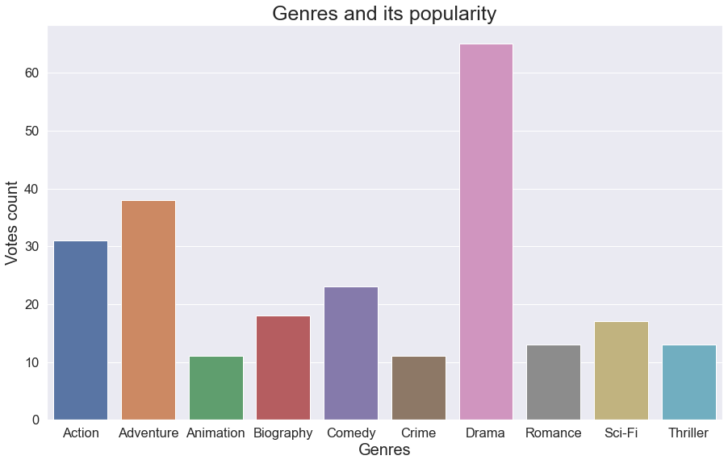

```python
plt.figure(figsize = (15,9))

sns.barplot(x = genre_top10.index, y = genre_top10.cnt)

# adding title and labels
plt.title("Genres and its popularity", fontsize = 25)
plt.xlabel("Genres", fontsize = 20)
plt.ylabel("Votes count", fontsize = 20)
plt.show()
```

#### It seems that majority of people enjoy watching Drama a lot followed by Adventure and Action. In order to make a blockbluster movie, one might want to focus on these genres.

## Gender and Genre

The Votes- and CVotes-related columns, you might have noticed the suffixes `F` and `M` indicating Female and Male. Since we have the vote counts for both males and females, across various age groups, let's now see how the popularity of genres vary between the two genders in the dataframe.

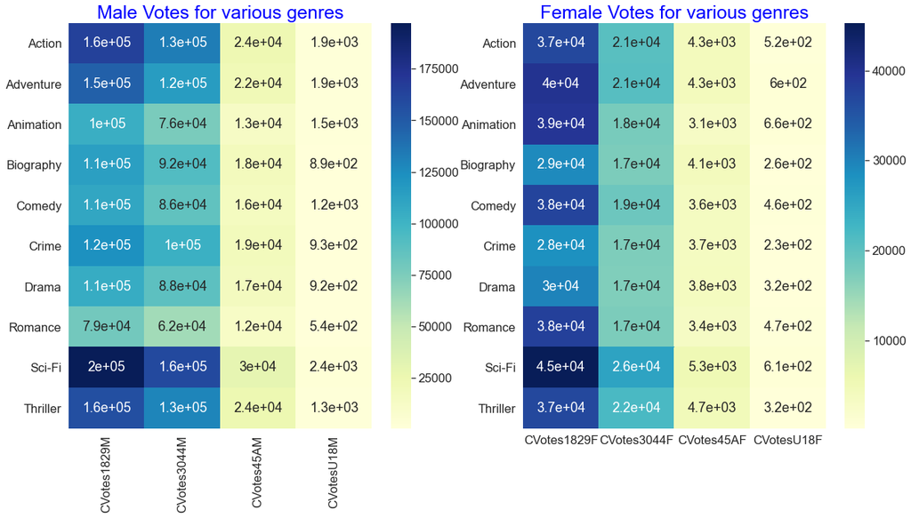

```python
# 1st set of heat maps for CVotes-related columns

plt.figure(figsize = (20,10))

# Subplot_1: Male Votes across genres
plt.subplot(1,2,1)
sns.heatmap((pd.pivot_table(data = genre_top10, index = genre_top10.index, values = ["CVotesU18M","CVotes1829M","CVotes3044M","CVotes45AM"], aggfunc = "mean" )), annot = True, cmap = "YlGnBu")
plt.title("Male Votes for various genres", fontdict = {"fontsize":25, "color": "Blue"})

# Subplot_2: Female Votes across genres
plt.subplot(1,2,2)
sns.heatmap((pd.pivot_table(data = genre_top10, index = genre_top10.index, values = ["CVotesU18F","CVotes1829F","CVotes3044F","CVotes45AF"], aggfunc = "mean" )), annot = True, cmap = "YlGnBu")
plt.title("Female Votes for various genres", fontdict = {"fontsize":25, "color": "Blue"})

plt.show()
```

#### A few inferences that can be seen from the heatmap above is that males have voted more than females, and Sci-Fi appears to be most popular among the 18-29 age group irrespective of their gender.

#### Under 18 age group is least voted group. Also Age category of 18-29 have voted more than other categories.

#### Romance and comedy genre is more popular in females as compared to males.

#### Action categorty is more popular in males as compared to females irrespective of age categories

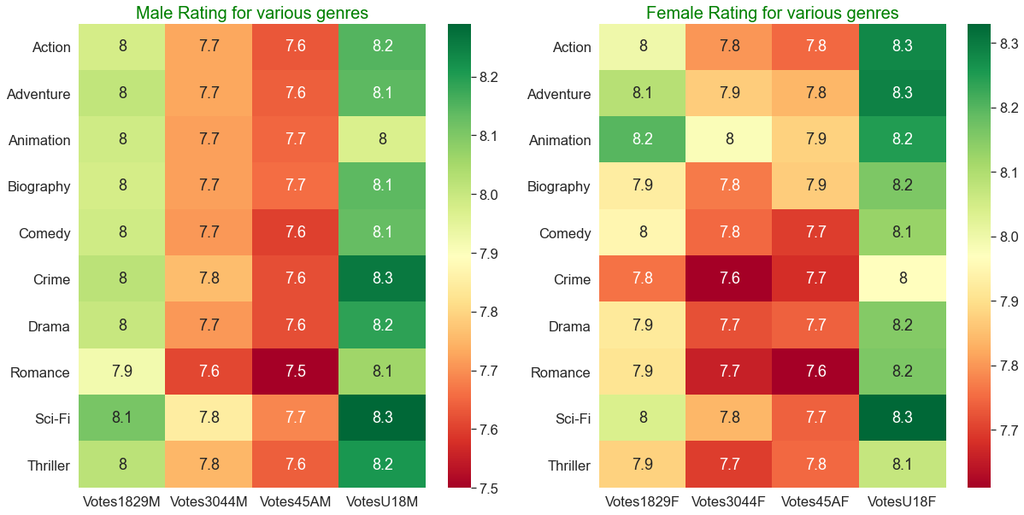

```python
# 2nd set of heat maps for Votes-related columns
plt.figure(figsize = (20,10))

# Subplot_1: Males rating across genres
plt.subplot(1,2,1)
plt.title("Male Rating for various genres", fontdict = {"fontsize":20, "color": "Green"})
sns.heatmap((pd.pivot_table(data = genre_top10, index = genre_top10.index, values = ["VotesU18M","Votes1829M","Votes3044M","Votes45AM"], aggfunc = "mean" )), annot = True, cmap = "RdYlGn")

# Subplot_2: Females rating across genres
plt.subplot(1,2,2)
plt.title("Female Rating for various genres", fontdict = {"fontsize":20, "color": "Green"})
sns.heatmap((pd.pivot_table(data = genre_top10, index = genre_top10.index, values = ["VotesU18F","Votes1829F","Votes3044F","Votes45AF"], aggfunc = "mean" )), annot = True, cmap = "RdYlGn")

plt.show()
```

#### Crime genre is highly rated by male under 18 category as compared to female.

#### Romance category is lowest rated genre by above 45 category irrespective of gender.

## US vs non-US Cross Analysis

The dataset contains both the US and non-US movies. Let's analyse how both the US and the non-US voters have responded to the US and the non-US movies.

```python
# Creating IFUS column

movies['IFUS']=movies['Country'].apply(lambda  x:"USA" if x=='USA' else "non-USA" )
movies.head()
```

|  | Title | title_year | budget | Gross | actor_1_name | actor_2_name | actor_3_name | actor_1_facebook_likes | actor_2_facebook_likes | actor_3_facebook_likes | IMDb_rating | genre_1 | genre_2 | genre_3 | MetaCritic | Runtime | CVotes10 | CVotes09 | CVotes08 | CVotes07 | CVotes06 | CVotes05 | CVotes04 | CVotes03 | CVotes02 | CVotes01 | CVotesMale | CVotesFemale | CVotesU18 | … |
| --- | --- | --- | --- | --- | --- | --- | --- | --- | --- | --- | --- | --- | --- | --- | --- | --- | --- | --- | --- | --- | --- | --- | --- | --- | --- | --- | --- | --- | --- | --- |
| 0 | Boyhood | 2014 | 4.0 | 25.359200 | Ellar Coltrane | Lorelei Linklater | Libby Villari | 230.0 | 193.0 | 127.0 | 7.9 | Drama | NaN | NaN | 10.0 | 165 | 49673 | 62055 | 76838 | 52238 | 23789 | 10431 | 4906 | 3071 | 2248 | 5086 | 183807 | 51558 | 1393 | … |
| 1 | 12 Years a Slave | 2013 | 20.0 | 56.667870 | QuvenzhanÃ© Wallis | Scoot McNairy | Taran Killam | 2000.0 | 660.0 | 500.0 | 8.1 | Biography | Drama | History | 9.6 | 134 | 75556 | 126223 | 161460 | 83070 | 27231 | 9603 | 4021 | 2420 | 1785 | 4739 | 313823 | 82012 | 1837 | … |
| 2 | Inside Out | 2015 | 175.0 | 356.454367 | Amy Poehler | Mindy Kaling | Phyllis Smith | 1000.0 | 767.0 | 384.0 | 8.2 | Animation | Adventure | Comedy | 9.4 | 95 | 87509 | 113244 | 119801 | 67153 | 24210 | 8542 | 3349 | 1872 | 1123 | 3450 | 244433 | 79081 | 3361 | … |
| 3 | La La Land | 2016 | 30.0 | 151.101803 | Ryan Gosling | Emma Stone | Amiée Conn | 14000.0 | 19000.0 | NaN | 8.2 | Comedy | Drama | Music | 9.3 | 128 | 74245 | 71191 | 64640 | 38831 | 17377 | 8044 | 3998 | 2839 | 2407 | 6802 | 157693 | 56713 | 2675 | … |
| 4 | Toy Story 3 | 2010 | 200.0 | 414.984497 | Tom Hanks | John Ratzenberger | Don Rickles | 15000.0 | 1000.0 | 721.0 | 8.3 | Animation | Adventure | Comedy | 9.2 | 103 | 139773 | 149992 | 158704 | 88289 | 31291 | 11850 | 4859 | 2932 | 2119 | 6586 | 389014 | 98386 | 3202 | … |

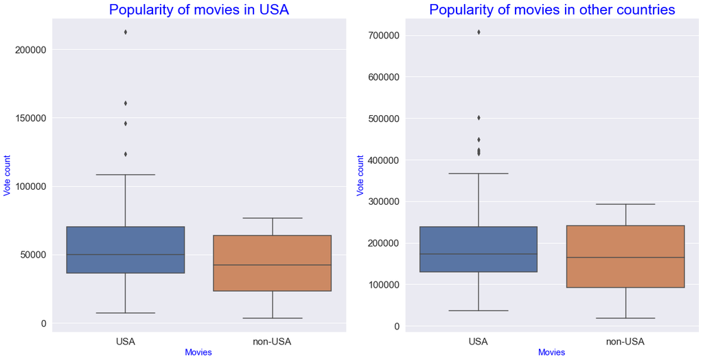

```python
# Box plot - 1: CVotesUS(y) vs IFUS(x)

plt.figure(figsize = (20,10))

#Subplot 1: Vote count in USA
plt.subplot(1,2,1)
sns.boxplot(x = "IFUS", y = "CVotesUS", data = movies)

# adding title and labels
plt.title("Popularity of movies in USA", fontdict = {"fontsize":25, "color": "Blue"})
plt.xlabel('Movies', fontdict = {"fontsize":15, "color": "Blue"})
plt.ylabel('Vote count', fontdict = {"fontsize":15, "color": "Blue"})

# Subplot 2: Vote count in other countries
plt.subplot(1,2,2)
sns.boxplot(x = "IFUS", y = "CVotesnUS", data = movies)

# adding title and labels
plt.title("Popularity of movies in other countries", fontdict = {"fontsize":25, "color": "Blue"})
plt.xlabel('Movies', fontdict = {"fontsize":15, "color": "Blue"})
plt.ylabel('Vote count', fontdict = {"fontsize":15, "color": "Blue"})

plt.show()
```

#### Outliers can be seen for both plots for USA movies. It seems that for some USA movies, vote count is maximum.

#### In other countries, USA movies are more popular than non-USA movies.

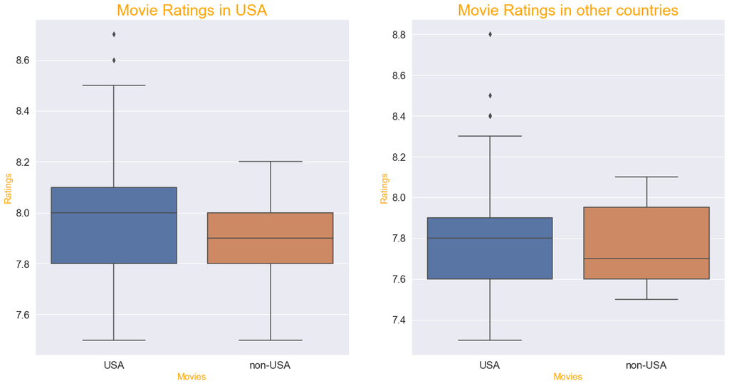

```python
# Box plot - 2: VotesUS(y) vs IFUS(x)


plt.figure(figsize = (20,10))

#Subplot 1: Movie Ratings in USA
plt.subplot(1,2,1)
sns.boxplot(x = "IFUS", y = "VotesUS", data = movies)

# adding title and labels
plt.title("Movie Ratings in USA", fontdict = {"fontsize":25, "color": "Orange"})
plt.xlabel('Movies', fontdict = {"fontsize":15, "color": "Orange"})
plt.ylabel('Ratings', fontdict = {"fontsize":15, "color": "Orange"})

# Subplot 2: Movie Ratings in other countries
plt.subplot(1,2,2)
sns.boxplot(x = "IFUS", y = "VotesnUS", data = movies)

# adding title and labels
plt.title("Movie Ratings in other countries", fontdict = {"fontsize":25, "color": "Orange"})
plt.xlabel('Movies', fontdict = {"fontsize":15, "color": "Orange"})
plt.ylabel('Ratings', fontdict = {"fontsize":15, "color": "Orange"})

plt.show()
```

#### USA movies are highly rated irrespective of countries

#### It seems that majority Rating for non-USA movies in other countries lies between 7.5 and 7.9

## Top 1000 Voters Vs Genres

The column `CVotes1000`represents the top 1000 voters on IMDb and gives the count for the number of these voters who have voted for a particular movie. Let's see how these top 1000 voters have voted across the genres.

```python
# Sorting by CVotes1000

genre_top10.sort_values('CVotes1000',ascending = False, inplace = True)
genre_top10
```

|  | CVotes10 | CVotes09 | CVotes08 | CVotes07 | CVotes06 | CVotes05 | CVotes04 | CVotes03 | CVotes02 | CVotes01 | CVotesMale | CVotesFemale | CVotesU18 | CVotesU18M | CVotesU18F | CVotes1829 | CVotes1829M | CVotes1829F | CVotes3044 | CVotes3044M | CVotes3044F | CVotes45A | CVotes45AM | CVotes45AF | CVotes1000 | CVotesUS | CVotesnUS | VotesM | VotesF | … |
| --- | --- | --- | --- | --- | --- | --- | --- | --- | --- | --- | --- | --- | --- | --- | --- | --- | --- | --- | --- | --- | --- | --- | --- | --- | --- | --- | --- | --- | --- | --- |
| Sci-Fi | 136781.0 | 148873.0 | 176646.0 | 106005.0 | 39518.0 | 14951.0 | 6583.0 | 3876.0 | 2715.0 | 6731.0 | 422437.0 | 83618.0 | 3017.0 | 2382.0 | 613.0 | 244808.0 | 197123.0 | 45269.0 | 188483.0 | 160141.0 | 25620.0 | 36127.0 | 30141.0 | 5340.0 | 714.0 | 80695.0 | 272068.0 | 7.96 | 7.96 | … |
| Action | 102144.0 | 114433.0 | 150895.0 | 94262.0 | 34688.0 | 12693.0 | 5386.0 | 3064.0 | 2115.0 | 5524.0 | 349581.0 | 67916.0 | 2460.0 | 1916.0 | 525.0 | 203684.0 | 164703.0 | 36996.0 | 155623.0 | 132836.0 | 20627.0 | 28862.0 | 24092.0 | 4269.0 | 681.0 | 69190.0 | 225998.0 | 7.85 | 7.92 | … |
| Thriller | 83207.0 | 112730.0 | 153336.0 | 90446.0 | 32003.0 | 11534.0 | 5021.0 | 2918.0 | 1982.0 | 4433.0 | 333785.0 | 68749.0 | 1664.0 | 1327.0 | 322.0 | 195463.0 | 156573.0 | 36989.0 | 153475.0 | 129421.0 | 21922.0 | 29590.0 | 24421.0 | 4654.0 | 669.0 | 63361.0 | 228944.0 | 7.87 | 7.82 | … |
| Adventure | 94596.0 | 105636.0 | 138482.0 | 86367.0 | 31896.0 | 11551.0 | 4817.0 | 2718.0 | 1835.0 | 4575.0 | 309468.0 | 71208.0 | 2520.0 | 1900.0 | 601.0 | 188563.0 | 146808.0 | 39896.0 | 138490.0 | 115795.0 | 20750.0 | 26641.0 | 21910.0 | 4267.0 | 662.0 | 61734.0 | 208034.0 | 7.85 | 8.01 | … |
| Crime | 52229.0 | 87919.0 | 129045.0 | 74671.0 | 25308.0 | 8971.0 | 3842.0 | 2246.0 | 1544.0 | 3383.0 | 261935.0 | 53330.0 | 1169.0 | 932.0 | 227.0 | 152504.0 | 122690.0 | 28310.0 | 121645.0 | 102671.0 | 17292.0 | 22867.0 | 18799.0 | 3658.0 | 620.0 | 49928.0 | 181338.0 | 7.87 | 7.72 | … |
| Comedy | 60157.0 | 77173.0 | 108993.0 | 69176.0 | 26099.0 | 9863.0 | 4237.0 | 2444.0 | 1712.0 | 3842.0 | 227088.0 | 65142.0 | 1650.0 | 1178.0 | 459.0 | 148032.0 | 109016.0 | 37509.0 | 106680.0 | 86346.0 | 18841.0 | 19954.0 | 15979.0 | 3621.0 | 605.0 | 49220.0 | 165869.0 | 7.83 | 7.88 | … |
| Biography | 47333.0 | 77867.0 | 123948.0 | 74054.0 | 23644.0 | 7702.0 | 2984.0 | 1639.0 | 1145.0 | 2849.0 | 240526.0 | 54827.0 | 1163.0 | 886.0 | 265.0 | 144627.0 | 114043.0 | 29157.0 | 111073.0 | 92158.0 | 17354.0 | 22550.0 | 18039.0 | 4126.0 | 600.0 | 45389.0 | 171004.0 | 7.84 | 7.88 | … |
| Drama | 52375.0 | 75928.0 | 109339.0 | 66456.0 | 23528.0 | 8497.0 | 3622.0 | 2078.0 | 1449.0 | 3250.0 | 225671.0 | 54956.0 | 1243.0 | 915.0 | 317.0 | 136485.0 | 105203.0 | 29896.0 | 106122.0 | 87644.0 | 16964.0 | 21612.0 | 17422.0 | 3806.0 | 585.0 | 44164.0 | 161234.0 | 7.84 | 7.85 | … |
| Animation | 61960.0 | 72566.0 | 104837.0 | 65707.0 | 22825.0 | 7551.0 | 2792.0 | 1430.0 | 911.0 | 2290.0 | 207544.0 | 65894.0 | 2166.0 | 1486.0 | 664.0 | 144420.0 | 103695.0 | 39314.0 | 94853.0 | 75824.0 | 17751.0 | 16305.0 | 12966.0 | 3063.0 | 578.0 | 47673.0 | 150424.0 | 7.85 | 8.12 | … |
| Romance | 42304.0 | 53037.0 | 82252.0 | 54833.0 | 21637.0 | 8530.0 | 3762.0 | 2130.0 | 1476.0 | 3082.0 | 162668.0 | 63572.0 | 1021.0 | 535.0 | 474.0 | 118201.0 | 79024.0 | 37926.0 | 80768.0 | 62253.0 | 17350.0 | 15719.0 | 12054.0 | 3381.0 | 548.0 | 37141.0 | 131254.0 | 7.75 | 7.83 | … |

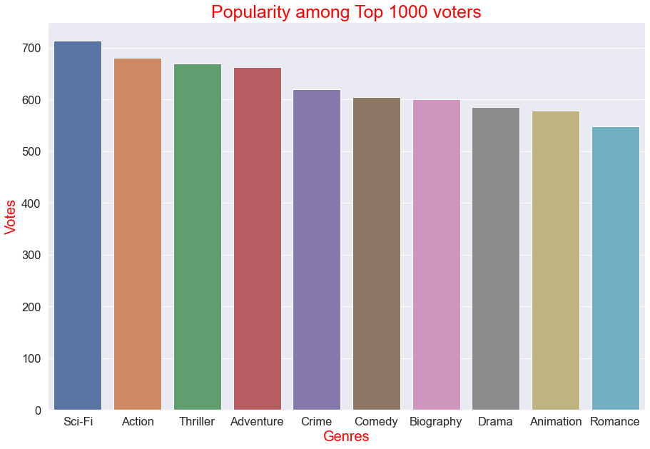

```python
# Bar plot
plt.figure(figsize = (15,10))
sns.barplot(data = genre_top10, x = genre_top10.index , y = "CVotes1000")

#adding and formatiing tile and labels
plt.title("Popularity among Top 1000 voters", fontdict = {"fontsize":25, "color": "Red"})
plt.xlabel('Genres', fontdict = {"fontsize": 20, "color": "Red"})
plt.ylabel('Votes', fontdict = {"fontsize": 20, "color": "Red"})

plt.show()
```

#### `Sci-Fi` genre seems to be most popular among the top 1000 voters, then comes `Action` and `thriller` movies. The genre `Romance` seems to be most unpopular among the top 1000 voters.

## Conclusions from Anaysis

#### 1. Star Wars: The Force Awakens has made the most profit & liked by both audience and critics. Also Deadpool, Django Unchanged, Whiplash and Gone Girl are some of the movies which are popular. These movies can be studied and further analysed to find reasons behind its success.

#### 2. The new movie can belong to either category R or PG-13 as these categories are popular among audience

#### 3. Budget of the movie has no significant effect on the movie becoming a success as we have seen that movies with huge budget has made very less profit. Also movies with small budget has made a huge profit. Budget for the new movie can be anything that suits the pockets!

#### 4. Genres plays an important role in deciding the fate of a movie. One might want to stick to genres which are popular in order to produce a blockbuster!

#### 5. Konwing the audience is very crucial. If one is looking to target audience with age group of 45 and above then romance genre is to be avoided. If the target audience is under 29, then sci-fic is the best choice.

#### 6. Thriller and Action genre is very popular in under 44 age group irrespective of the gender, so these genres will catch majority of the audience.

#### 7. Romance and comedy genres are more popular in females as compared to males, so if the aim is to attract female audience then one should go for these genres!